# Data analysis Morphological masked priming experiment on L1-ITA, L2-ENG bilingual speakers/readers

Paper titled *Masked morphological priming tracks the development of a fully mature lexical system in L2* - Submitted to JML in June 2019

Eva Viviani

Davide Crepaldi

17 April 2021

This script takes preprocessed data and produces all the analyses that are reported in the paper.

# clean WS, set WD and load data

This script works on the outcome of preProcessing.R, which you can upload here:

```r
read.table(paste(localGitDir, '/preprocessedData.txt', sep = ''), header = T, sep='\t', dec='.',
           colClasses=c("prime"="factor",
                        "target"="factor",
                        "lexicality"="factor",
                        "morphType"="factor",
                        "relatedness"="factor",
                        "aoa3.context"="factor",
                        "aoa4.contextMultling"="factor",
                        "aoa6.otherLang"="factor",
                        "language"="factor",
                         "gender"="factor",
                         "handedness"="factor"
                        )) -> masterFile;
```

# Participants

```r
temp <- unique(masterFile[,c('subject','age','gender','handedness')]);
```

```r
summary(temp)
```

```
##     subject           age           gender   handedness
##  Min.   : 1.00   Min.   :18.00   Female:56   Left :11
##  1st Qu.:21.00   1st Qu.:22.00   Male  :28   Right:73
##  Median :41.50   Median :24.00
##  Mean   :41.65   Mean   :24.32
##  3rd Qu.:62.25   3rd Qu.:26.00
##  Max.   :84.00   Max.   :34.00
```

# Stimuli

```r
temp <- unique(masterFile[,c('target','prime','lexicality','morphType','relatedness','freqTarget','freqPrime','lengthTarget','lengthPrime','nTarget','nPrime','language')]);
```

## Target features, ITA

Frequency of the targets, mean and sd

```
##   morphType freqTarget
## 1        op    3.63032
## 2        or    3.94728
## 3        tr    3.96898
```

```
##   morphType freqTarget
## 1        op  0.8779550
## 2        or  0.8523670
## 3        tr  0.6718303
```

Length of the targets, mean and sd

```
##   morphType lengthTarget
## 1        op         5.08
## 2        or         4.94
## 3        tr         5.16
```

```
##   morphType lengthTarget
## 1        op    0.8490042
## 2        or    0.8855746
## 3        tr    1.0704478
```

Coltheart’s N, mean and sd

```
##   morphType nTarget
## 1        op   20.12
## 2        or   21.56
## 3        tr   18.14
```

```
##   morphType  nTarget
## 1        op 11.91492
## 2        or 13.45274
## 3        tr 11.32265
```

## Prime features, ITA

Frequency of the primes, mean and sd

```
##   relatedness morphType freqPrime
## 1        ctrl        op  3.095800
## 2         rel        op  3.157653
## 3        ctrl        or  3.198040
## 4         rel        or  3.228920
## 5        ctrl        tr  2.913200
## 6         rel        tr  2.923460
```

```
##   relatedness morphType freqPrime
## 1        ctrl        op 0.8518056
## 2         rel        op 0.7863899
## 3        ctrl        or 0.6784778
## 4         rel        or 0.6984253
## 5        ctrl        tr 0.6843910
## 6         rel        tr 0.8404621
```

Length of the primes, mean and sd

```
##   relatedness morphType lengthPrime
## 1        ctrl        op        7.96
## 2         rel        op        7.96
## 3        ctrl        or        7.52
## 4         rel        or        7.52
## 5        ctrl        tr        7.70
## 6         rel        tr        7.70
```

```
##   relatedness morphType lengthPrime
## 1        ctrl        op    1.211509
## 2         rel        op    1.211509
## 3        ctrl        or    1.182181
## 4         rel        or    1.182181
## 5        ctrl        tr    1.249490
## 6         rel        tr    1.249490
```

Coltheart’s N, mean and sd

```
##   relatedness morphType nPrime
## 1        ctrl        op   3.84
## 2         rel        op   3.52
## 3        ctrl        or   3.54
## 4         rel        or   4.24
## 5        ctrl        tr   3.82
## 6         rel        tr   3.62
```

```
##   relatedness morphType   nPrime
## 1        ctrl        op 2.937165
## 2         rel        op 2.628261
## 3        ctrl        or 2.525058
## 4         rel        or 6.169576
## 5        ctrl        tr 2.973969
## 6         rel        tr 2.905940
```

# Outliers trimming, ITA

```r
subset(masterFile, language=="ita") -> masterFileIta;
```

The following code generates target and sbj means and SDs, and the outlier graphs in the file ‘ita.jpg’.

```r
sbj.id <- masterFileIta$subject;
acc <- masterFileIta$accuracy;
lexicality <- tolower(masterFileIta$lexicality);
target <- masterFileIta$target;
rt <- masterFileIta$rt;

source(paste(localGitDir, "/tools/diagnostics.R", sep=''));
outlierGraphStore <- localGitDir;
diagnostics.f(rt = rt, acc = acc, sbj.id = sbj.id, target = target, lexicality = lexicality, paste(outlierGraphStore, "ita", sep=""));
rm(rt, target, lexicality, acc, sbj.id);
```

Based on the graphs in ‘ita.jpg’: we exclude **sbj 2** and **31** for an abnormal error rate on nonwords (<80%); and target words **GUANO**, **UGGIA** and **VELLO** with abnormally low accuracy (<60%). **sbj 15** is excluded because s/he reported having seen the primes.

Individual RTs distribution seems fine, but let’s check the tails more carefully:

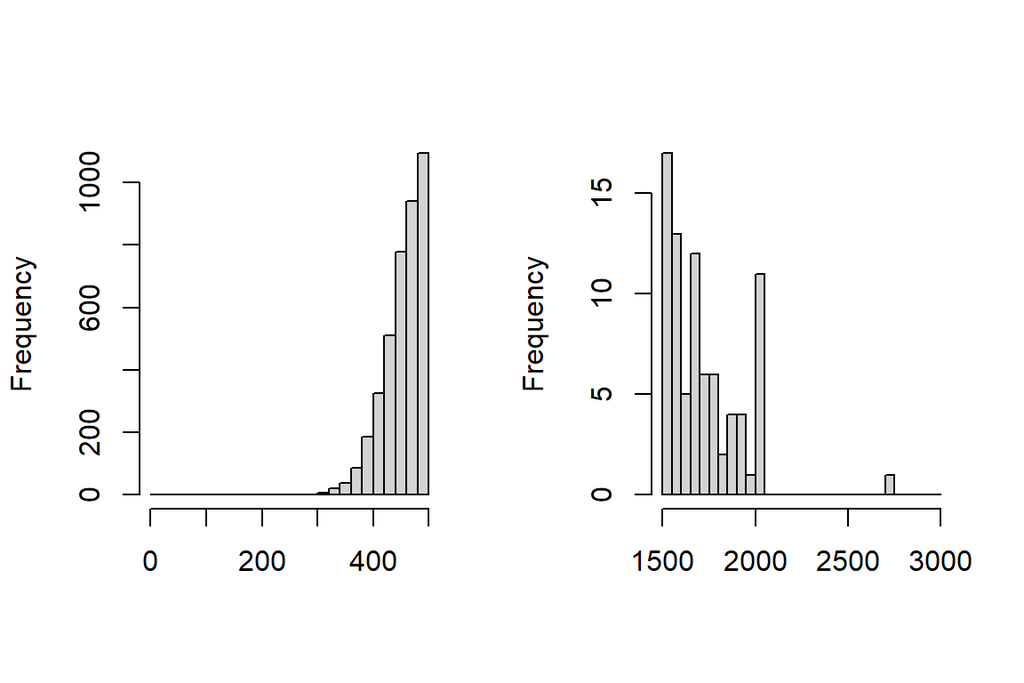

```r
dataItaAcc <- subset(masterFileIta, lexicality=="word");
dataItaTemp <- subset(dataItaAcc, accuracy==1);
dataIta <- subset(dataItaTemp, rt>280 & rt<2000 & subject!=15 & subject!=2 & subject!=31 & target!= "guano" & target!= "uggia" & target!= "vello");
```

- Number of datapoints trimmed: 526
- Percentage of datapoints trimmed: 4.56%
- Number of datapoints left: 11009

Summary of the dataset trimmed:

```r
summary(dataIta)
```

```
##     subject           age           gender     handedness     trialCount
##  Min.   : 1.00   Min.   :18.00   Female:7362   Left :1284   Min.   :  1.0
##  1st Qu.:22.00   1st Qu.:22.00   Male  :3647   Right:9725   1st Qu.: 77.0
##  Median :43.00   Median :24.00                              Median :150.0
##  Mean   :42.19   Mean   :24.44                              Mean   :150.5
##  3rd Qu.:62.00   3rd Qu.:27.00                              3rd Qu.:225.0
##  Max.   :84.00   Max.   :34.00                              Max.   :300.0
##
##        rt              resp    trialType           lexicality    morphType
##  Min.   : 284.0   Min.   :2   Length:11009       nonword:    0   op:3717
##  1st Qu.: 499.0   1st Qu.:2   Class :character   word   :11009   or:3621
##  Median : 564.0   Median :2   Mode  :character                   tr:3671
##  Mean   : 594.5   Mean   :2
##  3rd Qu.: 652.0   3rd Qu.:2
##  Max.   :1960.0   Max.   :2
##
##      target            prime       relatedness   freqTarget      freqPrime
##  abito  :   78   abitudine:   39   ctrl:5498   Min.   :1.367   Min.   :1.191
##  ballo  :   78   albergo  :   39   rel :5511   1st Qu.:3.435   1st Qu.:2.562
##  banca  :   78   alleanza :   39               Median :3.989   Median :3.039
##  cambio :   78   areola   :   39               Mean   :3.915   Mean   :3.093
##  corda  :   78   ballatoio:   39               3rd Qu.:4.450   3rd Qu.:3.606
##  corte  :   78   bancario :   39               Max.   :5.671   Max.   :4.909
##  (Other):10541   (Other)  :10775                               NA's   :37
##   lengthTarget    lengthPrime        nTarget          nPrime
##  Min.   :3.000   Min.   : 5.000   Min.   : 0.00   Min.   : 0.000
##  1st Qu.:4.000   1st Qu.: 7.000   1st Qu.:11.00   1st Qu.: 2.000
##  Median :5.000   Median : 8.000   Median :18.00   Median : 3.000
##  Mean   :5.064   Mean   : 7.756   Mean   :20.13   Mean   : 3.723
##  3rd Qu.:6.000   3rd Qu.: 9.000   3rd Qu.:30.00   3rd Qu.: 5.000
##  Max.   :8.000   Max.   :10.000   Max.   :47.00   Max.   :36.000
##
##    rotation         language      oscTarget        accuracy phonemicFluency
##  Length:11009       eng:    0   Min.   : NA     Min.   :1   Min.   : 0.00
##  Class :character   ita:11009   1st Qu.: NA     1st Qu.:1   1st Qu.:17.00
##  Mode  :character               Median : NA     Median :1   Median :23.00
##                                 Mean   :NaN     Mean   :1   Mean   :22.52
##                                 3rd Qu.: NA     3rd Qu.:1   3rd Qu.:27.00
##                                 Max.   : NA     Max.   :1   Max.   :45.00
##                                 NA's   :11009
```

[output cut: 9 more lines]

```
##  Min.   : 8.00   Min.   :1.000     Min.   : 0.000   Min.   :1.00
##  1st Qu.:14.00   1st Qu.:3.000     1st Qu.: 6.000   1st Qu.:2.00
##  Median :15.00   Median :5.000     Median : 6.000   Median :3.00
##  Mean   :15.28   Mean   :4.593     Mean   : 6.544   Mean   :3.12
##  3rd Qu.:17.00   3rd Qu.:6.000     3rd Qu.: 8.000   3rd Qu.:4.00
##  Max.   :19.00   Max.   :6.000     Max.   :15.000   Max.   :5.00
##
##  aoa3.context  aoa4.contextMultling aoa5.selfRatedProf aoa6.otherLang
##  home  :1433   no :8446             Min.   :1.00       no :2673
##  school:9576   yes:2563             1st Qu.:3.00       yes:8336
##                                     Median :4.00
##                                     Mean   :3.54
##                                     3rd Qu.:4.00
##                                     Max.   :5.00
##
```

# Outliers trimming, ENG

```r
subset(masterFile, language=="eng") -> masterFileEng;
```

The following code generates target and sbj means and SDs, and the outlier graphs in the file ‘eng.jpg’

```r
sbj.id <- masterFileEng$subject;
acc <- masterFileEng$accuracy;
lexicality <- masterFileEng$lexicality;
lexicality <- tolower(masterFileEng$lexicality);
target <- masterFileEng$target;
rt <- masterFileEng$rt;

outlierGraphStore <- localGitDir;
diagnostics.f(rt = rt, acc = acc, sbj.id = sbj.id, target = target, lexicality = lexicality, paste(outlierGraphStore, "eng1", sep=""));
rm(rt, target, lexicality, acc, sbj.id);
```

**sbj 26** likely confused YES/NO buttons. Let’s check the frequency effect, just to confirm:

```r
cor(masterFileEng[masterFileEng$subject==26 & masterFileEng$lexicality=='word', c('rt','freqTarget')], use = 'pairwise.complete.obs'); #it's unlikely s/he responded randomly. So, let's fix this:
```

```
##                    rt freqTarget
## rt          1.0000000 -0.2116401
## freqTarget -0.2116401  1.0000000
```

```r
masterFileEng$accuracy[masterFileEng$subject==26] <- car::recode(masterFileEng$accuracy[masterFileEng$subject==26], "1=0;0=1");
```

ok, we can now rerun diagnostics:

```r
sbj.id <- masterFileEng$subject;
acc <- masterFileEng$accuracy;
lexicality <- masterFileEng$lexicality;
lexicality <- tolower(masterFileEng$lexicality);
target <- masterFileEng$target;
rt <- masterFileEng$rt;

diagnostics.f(rt = rt, acc = acc, sbj.id = sbj.id, target = target, lexicality = lexicality, paste(outlierGraphStore, "eng", sep=""));
rm(outlierGraphStore, rt, target, lexicality, acc, sbj.id);
```

Based on the graphs in ‘eng.jpg’: we exclude **sbj 22** for a very atypical performance (substantially below chance) on nonwords. We would exclude no target, even though some of them do elicit bad performance–the distribution is very continuous, no sign of glaring outliers. Plus, this is L2, so low performance is to be expected. **sbj 15** and **43** reported having seen the primes.

Individual RTs distribution seems fine, but let’s check the tails more carefully:

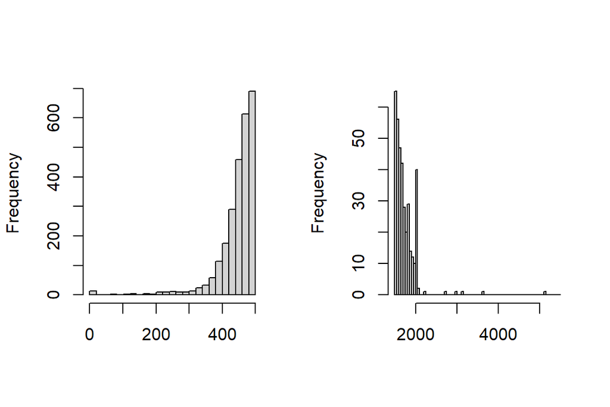

- First graph: very continuous towards zero, plus a few zeroes. Anyway, deflection in the curve around 300ms, so let’s cut there.
- Second graph: clear outliers over 2000ms

```r
dataEngAcc <- subset(masterFileEng, lexicality=="word");
dataEngTemp <- subset(dataEngAcc, accuracy==1);
dataEng <- subset(dataEngTemp, rt>300 & rt<2000 & subject!=15 & subject!=22 & subject!=43);
```

- Number of datapoints trimmed: 281
- Percentage of datapoints trimmed: 3.05%
- Number of datapoints left: 8938

Summary of the trimmed dataset:

```r
summary(dataEng);
```

```
##     subject           age           gender     handedness     trialCount
##  Min.   : 1.00   Min.   :18.00   Female:6170   Left : 907   Min.   :  1.0
##  1st Qu.:20.00   1st Qu.:22.00   Male  :2768   Right:8031   1st Qu.: 74.0
##  Median :42.00   Median :24.00                              Median :150.0
##  Mean   :41.76   Mean   :24.19                              Mean   :149.8
##  3rd Qu.:63.00   3rd Qu.:26.00                              3rd Qu.:224.0
##  Max.   :84.00   Max.   :34.00                              Max.   :300.0
##
##        rt              resp        trialType           lexicality   morphType
##  Min.   : 312.0   Min.   :0.000   Length:8938        nonword:   0   op:2946
##  1st Qu.: 544.0   1st Qu.:2.000   Class :character   word   :8938   or:2762
##  Median : 622.0   Median :2.000   Mode  :character                  tr:3230
##  Mean   : 672.1   Mean   :1.986
##  3rd Qu.: 742.0   3rd Qu.:2.000
##  Max.   :1998.0   Max.   :2.000
##
##      target           prime      relatedness   freqTarget      freqPrime
##  again  :  78   against  :  40   ctrl:4388   Min.   :1.650   Min.   :1.170
##  angel  :  78   angelic  :  40   rel :4550   1st Qu.:3.555   1st Qu.:2.820
##  legend :  78   cloudless:  40               Median :4.050   Median :3.410
##  unit   :  78   dreamer  :  40               Mean   :4.058   Mean   :3.472
##  blood  :  77   drunkard :  40               3rd Qu.:4.680   3rd Qu.:4.080
##  fruit  :  77   extract  :  40               Max.   :5.840   Max.   :6.290
##  (Other):8472   (Other)  :8698
##   lengthTarget    lengthPrime        nTarget           nPrime
##  Min.   :3.000   Min.   : 5.000   Min.   : 0.000   Min.   : 0.000
##  1st Qu.:4.000   1st Qu.: 6.000   1st Qu.: 4.000   1st Qu.: 0.000
##  Median :5.000   Median : 7.000   Median : 7.000   Median : 1.000
##  Mean   :4.828   Mean   : 7.215   Mean   : 8.785   Mean   : 2.485
##  3rd Qu.:5.000   3rd Qu.: 8.000   3rd Qu.:12.000   3rd Qu.: 3.000
##  Max.   :7.000   Max.   :13.000   Max.   :44.000   Max.   :24.000
##
##    rotation         language     oscTarget          accuracy phonemicFluency
##  Length:8938        eng:8938   Min.   :-0.0940   Min.   :1   Min.   : 0.00
##  Class :character   ita:   0   1st Qu.: 0.2630   1st Qu.:1   1st Qu.:17.00
##  Mode  :character              Median : 0.6230   Median :1   Median :23.00
##                                Mean   : 0.5767   Mean   :1   Mean   :22.61
##                                3rd Qu.: 0.8990   3rd Qu.:1   3rd Qu.:27.00
##                                Max.   : 1.0000   Max.   :1   Max.   :45.00
##                                NA's   :155
```

[output cut: 9 more lines]

```
##  Min.   : 8.00   Min.   :1.00      Min.   : 0.000   Min.   :1.000
##  1st Qu.:14.00   1st Qu.:3.00      1st Qu.: 6.000   1st Qu.:2.000
##  Median :16.00   Median :5.00      Median : 6.000   Median :3.000
##  Mean   :15.34   Mean   :4.59      Mean   : 6.433   Mean   :3.174
##  3rd Qu.:17.00   3rd Qu.:6.00      3rd Qu.: 8.000   3rd Qu.:4.000
##  Max.   :19.00   Max.   :6.00      Max.   :15.000   Max.   :5.000
##
##  aoa3.context  aoa4.contextMultling aoa5.selfRatedProf aoa6.otherLang
##  home  :1231   no :6811             Min.   :1.000      no :2062
##  school:7707   yes:2127             1st Qu.:3.000      yes:6876
##                                     Median :3.000
##                                     Mean   :3.526
##                                     3rd Qu.:4.000
##                                     Max.   :5.000
##
```

# Descriptive statistics

- Mean accuracy ITA: 95%
- Mean RT ITA: 594.51 ms
- Mean accuracy ENG: 76%
- Mean RT ENG: 672.1 ms

Mean RT and sd by relatedness and morphtype - ITA dataset:

```
##   relatedness morphType       rt
## 1        ctrl        op 614.4428
## 2         rel        op 598.8104
## 3        ctrl        or 607.0192
## 4         rel        or 606.5746
## 5        ctrl        tr 589.1723
## 6         rel        tr 551.3402
```

```
##   relatedness morphType       rt
## 1        ctrl        op 150.3067
## 2         rel        op 157.5980
## 3        ctrl        or 145.9696
## 4         rel        or 155.8299
## 5        ctrl        tr 131.0569
## 6         rel        tr 126.2728
```

Mean RT and sd by relatedness and morphtype - ENG dataset:

```
##   relatedness morphType       rt
## 1        ctrl        op 685.2774
## 2         rel        op 666.6475
## 3        ctrl        or 703.1108
## 4         rel        or 688.2460
## 5        ctrl        tr 667.2606
## 6         rel        tr 630.8267
```

```
##   relatedness morphType       rt
## 1        ctrl        op 196.6292
## 2         rel        op 214.0158
## 3        ctrl        or 214.4669
## 4         rel        or 207.4222
## 5        ctrl        tr 177.6199
## 6         rel        tr 183.6509
```

# Modelling

The code through which we generated the dataset is reported here below.

## Italian, L1

Constrasts:

```
##      rel
## ctrl   0
## rel    1
```

```
##    op tr
## or  0  0
## op  1  0
## tr  0  1
```

```r
itaglmer0<- glmer(rt ~ 1 + (1|subject) + (1|target), data= dataIta, family=Gamma(link="identity"));
```

```r
itaglmer1<- glmer(rt ~ trialCount + rotation + (1|subject) + (1|target), data= dataIta, family=Gamma(link="identity"));
```

```r
anova(itaglmer0, itaglmer1);
```

```
## Data: dataIta
## Models:
## itaglmer0: rt ~ 1 + (1 | subject) + (1 | target)
## itaglmer1: rt ~ trialCount + rotation + (1 | subject) + (1 | target)
##           npar    AIC    BIC logLik deviance  Chisq Df Pr(>Chisq)
## itaglmer0    4 134591 134620 -67291   134583
## itaglmer1    6 134593 134637 -67291   134581 1.4915  2     0.4744
```

no effect of rotation here

```r
itaglmer1a<- glmer(rt ~ freqTarget + lengthTarget + nTarget + (1|subject) + (1|target), data= dataIta, family=Gamma(link="identity"));
```

```r
anova(itaglmer0, itaglmer1a);
```

```
## Data: dataIta
## Models:
## itaglmer0: rt ~ 1 + (1 | subject) + (1 | target)
## itaglmer1a: rt ~ freqTarget + lengthTarget + nTarget + (1 | subject) + (1 |
## itaglmer1a:     target)
##            npar    AIC    BIC logLik deviance  Chisq Df Pr(>Chisq)
## itaglmer0     4 134591 134620 -67291   134583
## itaglmer1a    7 134540 134592 -67263   134526 56.328  3  3.576e-12 ***
## ---
## Signif. codes:  0 '***' 0.001 '**' 0.01 '*' 0.05 '.' 0.1 ' ' 1
```

strong improvement in GoF

```r
car::Anova(itaglmer1a)
```

```
## Analysis of Deviance Table (Type II Wald chisquare tests)
##
## Response: rt
##                 Chisq Df Pr(>Chisq)
## freqTarget   234.6265  1     <2e-16 ***
## lengthTarget   1.6941  1     0.1931
## nTarget        0.2406  1     0.6238
## ---
## Signif. codes:  0 '***' 0.001 '**' 0.01 '*' 0.05 '.' 0.1 ' ' 1
```

To which only freq seems to contribute. We introduce the variables of interest now:

```r
itaglmer2<- glmer(rt ~ relatedness * morphType + freqTarget + (1|subject) + (1|target), data= dataIta, family=Gamma(link="identity"), control=glmerControl(optimizer="bobyqa", optCtrl=list(maxfun=2e5)));
```

```r
summary(itaglmer2)-> modelsum2
car::Anova(itaglmer2)-> itaglmer2.anova
itaglmer2.anova
```

```
## Analysis of Deviance Table (Type II Wald chisquare tests)
##
## Response: rt
##                         Chisq Df Pr(>Chisq)
## relatedness            63.282  1  1.791e-15 ***
## morphType              70.279  2  5.484e-16 ***
## freqTarget            420.382  1  < 2.2e-16 ***
## relatedness:morphType 228.836  2  < 2.2e-16 ***
## ---
## Signif. codes:  0 '***' 0.001 '**' 0.01 '*' 0.05 '.' 0.1 ' ' 1
```

With “orthographic” and “unrelated/ctrl” as base contrast:

```r
knitr::kable(round(modelsum2$coefficients, 4))
```

|  | Estimate | Std. Error | t value | Pr(>\|z\|) |
| --- | --- | --- | --- | --- |
| (Intercept) | 800.1365 | 3.9876 | 200.6554 | 0.0000 |
| relatednessrel | -1.3974 | 1.8425 | -0.7584 | 0.4482 |
| morphTypeop | -11.6087 | 2.6859 | -4.3221 | 0.0000 |
| morphTypetr | -17.7294 | 2.7439 | -6.4614 | 0.0000 |
| freqTarget | -44.2176 | 2.1566 | -20.5032 | 0.0000 |
| relatednessrel:morphTypeop | -14.2715 | 2.2082 | -6.4628 | 0.0000 |
| relatednessrel:morphTypetr | -36.8151 | 2.5344 | -14.5262 | 0.0000 |

Following the suggestion of a reviewer, we check here that the results remain the same when we exclude the participants who were also excluded in the L2 analysis (i.e., when the set of participants is identical in in the L1 and L2 experiments);

```r
itaglmer2check <- glmer(rt ~ relatedness * morphType + freqTarget + (1|subject) + (1|target), data=subset(dataIta, subject!=15 & subject!=22 & subject!=43), family=Gamma(link="identity"), control=glmerControl(optimizer="bobyqa", optCtrl=list(maxfun=2e5)));
```

```r
knitr::kable(round(summary(itaglmer2check)$coefficients,6));
```

|  | Estimate | Std. Error | t value | Pr(>\|z\|) |
| --- | --- | --- | --- | --- |
| (Intercept) | 798.388204 | 3.212482 | 248.526924 | 0.000000 |
| relatednessrel | -1.745232 | 2.193828 | -0.795519 | 0.426312 |
| morphTypeop | -12.345671 | 4.563239 | -2.705462 | 0.006821 |
| morphTypetr | -17.631361 | 7.002128 | -2.518000 | 0.011802 |
| freqTarget | -43.963563 | 2.632072 | -16.703027 | 0.000000 |
| relatednessrel:morphTypeop | -12.956980 | 2.636726 | -4.914041 | 0.000001 |
| relatednessrel:morphTypetr | -36.234090 | 2.894386 | -12.518748 | 0.000000 |

```r
car::Anova(itaglmer2check);
```

```
## Analysis of Deviance Table (Type II Wald chisquare tests)
##
## Response: rt
##                          Chisq Df Pr(>Chisq)
## relatedness            77.8429  1    < 2e-16 ***
## morphType               6.8177  2    0.03308 *
## freqTarget            278.9911  1    < 2e-16 ***
## relatedness:morphType 161.4778  2    < 2e-16 ***
## ---
## Signif. codes:  0 '***' 0.001 '**' 0.01 '*' 0.05 '.' 0.1 ' ' 1
```

Let’s relevel for transparent versus opaque condition:

```r
dataIta$morphType <- relevel(dataIta$morphType, "op");
```

```r
itaglmer2c<- glmer(rt ~ relatedness * morphType + freqTarget + (1|subject) + (1|target), data= dataIta, family=Gamma(link="identity"), control=glmerControl(optimizer="bobyqa", optCtrl=list(maxfun=2e5)));
```

```r
summary(itaglmer2c)->modelsum2c
```

```r
knitr::kable(round(modelsum2c$coefficients, 4))
```

|  | Estimate | Std. Error | t value | Pr(>\|z\|) |
| --- | --- | --- | --- | --- |
| (Intercept) | 788.5277 | 4.0865 | 192.9579 | 0.0000 |
| relatednessrel | -15.6690 | 2.1883 | -7.1604 | 0.0000 |
| morphTypeor | 11.6097 | 4.3057 | 2.6964 | 0.0070 |
| morphTypetr | -6.1195 | 3.3664 | -1.8178 | 0.0691 |
| freqTarget | -44.2179 | 2.0014 | -22.0930 | 0.0000 |
| relatednessrel:morphTypeor | 14.2720 | 2.7368 | 5.2148 | 0.0000 |
| relatednessrel:morphTypetr | -22.5436 | 3.2858 | -6.8608 | 0.0000 |

### Summary of the results for ITA dataset

The model itaglmer2 shows a significant interaction between relatedness and morphtype [$\chi^2$ = 228.84, $Df$ = 2, *p* $<$ 0.0001], such that among related trials there were faster reaction times to orthographic trials compared to opaque trials [$\beta$ = -14.27, $Std.Error$ = 2.21, $t$ = -6.46, *p* $<$ 0.0001], and to transparent trials [$\beta$ = -36.82, $Std.Error$ = 2.53, $t$ = -14.53, *p* $<$ 0.0001]. By setting the base contrast to opaque trials, itaglmer2c shows that opaque trials are faster than transparent trials [$\beta$ = -22.54, $Std.Error$ = 3.29, $t$ = -6.86, *p* $<$ 0.0001].

## English, L2

Set contrasts:

```
##      rel
## ctrl   0
## rel    1
```

```
##    op tr
## or  0  0
## op  1  0
## tr  0  1
```

```r
engglmer0 <- glmer(rt ~ 1+ (1|subject) + (1|target), data = dataEng,
      family=Gamma(link="identity"));
```

```r
engglmer1 <- glmer(rt ~ trialCount + rotation+ (1|subject) + (1|target), data = dataEng, family=Gamma(link="identity"));
```

```r
anova(engglmer0, engglmer1);
```

```
## Data: dataEng
## Models:
## engglmer0: rt ~ 1 + (1 | subject) + (1 | target)
## engglmer1: rt ~ trialCount + rotation + (1 | subject) + (1 | target)
##           npar    AIC    BIC logLik deviance  Chisq Df Pr(>Chisq)
## engglmer0    4 113778 113806 -56885   113770
## engglmer1    6 113778 113820 -56883   113766 3.8608  2     0.1451
```

Again like in the ITA dataset, no effect of rotation here.

```r
engglmer1c <- glmer(rt ~ freqTarget + lengthTarget + nTarget + (1|subject) + (1|target), data = dataEng, family=Gamma(link="identity"), control=glmerControl(optimizer="bobyqa", optCtrl=list(maxfun=2e5)))
```

```r
anova(engglmer0, engglmer1c);
```

```
## Data: dataEng
## Models:
## engglmer0: rt ~ 1 + (1 | subject) + (1 | target)
## engglmer1c: rt ~ freqTarget + lengthTarget + nTarget + (1 | subject) + (1 |
## engglmer1c:     target)
##            npar    AIC    BIC logLik deviance  Chisq Df Pr(>Chisq)
## engglmer0     4 113778 113806 -56885   113770
## engglmer1c    7 113719 113769 -56853   113705 64.523  3  6.344e-14 ***
## ---
## Signif. codes:  0 '***' 0.001 '**' 0.01 '*' 0.05 '.' 0.1 ' ' 1
```

strong improvement in GoF

```r
car::Anova(engglmer1c)
```

```
## Analysis of Deviance Table (Type II Wald chisquare tests)
##
## Response: rt
##                 Chisq Df Pr(>Chisq)
## freqTarget   301.5128  1     <2e-16 ***
## lengthTarget  92.6719  1     <2e-16 ***
## nTarget        0.0036  1     0.9523
## ---
## Signif. codes:  0 '***' 0.001 '**' 0.01 '*' 0.05 '.' 0.1 ' ' 1
```

Frequency and length contribute.

We introduce our variable of interest now:

```r
engglmer2 <- glmer(rt ~ relatedness * morphType + freqTarget + lengthTarget + (1|subject) + (1|target), data = dataEng, family=Gamma(link="identity"), control=glmerControl(optimizer="bobyqa", optCtrl=list(maxfun=2e5)))
```

```r
engglmer2.anova <- car::Anova(engglmer2)
engglmer2.modelsum <- summary(engglmer2)
engglmer2.anova
```

```
## Analysis of Deviance Table (Type II Wald chisquare tests)
##
## Response: rt
##                          Chisq Df Pr(>Chisq)
## relatedness           115.6393  1  < 2.2e-16 ***
## morphType               3.3445  2     0.1878
## freqTarget            663.8526  1  < 2.2e-16 ***
## lengthTarget           97.4373  1  < 2.2e-16 ***
## relatedness:morphType  32.9506  2  6.996e-08 ***
## ---
## Signif. codes:  0 '***' 0.001 '**' 0.01 '*' 0.05 '.' 0.1 ' ' 1
```

Summary of the engglmer2 model:

```r
knitr::kable(round(engglmer2.modelsum$coefficients, 4))
```

|  | Estimate | Std. Error | t value | Pr(>\|z\|) |
| --- | --- | --- | --- | --- |
| (Intercept) | 1148.3132 | 3.0478 | 376.7719 | 0.0000 |
| relatednessrel | -19.0099 | 2.5847 | -7.3548 | 0.0000 |
| morphTypeop | 0.0623 | 3.5746 | 0.0174 | 0.9861 |
| morphTypetr | -0.7171 | 4.8117 | -0.1490 | 0.8815 |
| freqTarget | -72.1990 | 2.8022 | -25.7653 | 0.0000 |
| lengthTarget | -26.4356 | 2.6781 | -9.8710 | 0.0000 |
| relatednessrel:morphTypeop | -5.6052 | 2.9651 | -1.8904 | 0.0587 |
| relatednessrel:morphTypetr | -17.1599 | 3.1044 | -5.5275 | 0.0000 |

We set the base contrast on the opaque condition and re-run the model:

```r
dataEng$morphType <- relevel(dataEng$morphType, "op");
```

```r
engglmer2c <- glmer(rt ~ relatedness * morphType + freqTarget + lengthTarget + (1|subject) + (1|target), data = dataEng, family=Gamma(link="identity"), control=glmerControl(optimizer="bobyqa", optCtrl=list(maxfun=2e5)))
```

```r
engglmer2c.modelsum <- summary(engglmer2c)
```

```r
knitr::kable(round(engglmer2c.modelsum$coefficients, 4))
```

|  | Estimate | Std. Error | t value | Pr(>\|z\|) |
| --- | --- | --- | --- | --- |
| (Intercept) | 1148.3958 | 4.1030 | 279.8895 | 0.0000 |
| relatednessrel | -24.6153 | 2.7411 | -8.9800 | 0.0000 |
| morphTypeor | -0.0644 | 4.3638 | -0.0148 | 0.9882 |
| morphTypetr | -0.7773 | 8.3555 | -0.0930 | 0.9259 |
| freqTarget | -72.2010 | 3.6174 | -19.9592 | 0.0000 |
| lengthTarget | -26.4380 | 3.5915 | -7.3613 | 0.0000 |
| relatednessrel:morphTypeor | 5.6057 | 4.1280 | 1.3580 | 0.1745 |
| relatednessrel:morphTypetr | -11.5547 | 3.0514 | -3.7866 | 0.0002 |

### Summary of the results for ENG dataset

The model engglmer2 shows a significant interaction between relatedness and morphtype [$\chi^2$ = 32.95, $Df$ = 2, *p* $<$ 0.0001], such that among related trials there were faster reaction times to orthographic trials compared to opaque trials, although only marginally significant [$\beta$ = -5.61, $Std.Error$ = 2.97, $t$ = -1.89, *p* = 0.0587], and to transparent trials [$\beta$ = -17.16, $Std.Error$ = 3.1, $t$ = -5.53, *p* $<$ 0.0001]. By setting the base contrast to opaque trials, engglmer2c shows that opaque trials are faster than transparent trials [$\beta$ = -11.55, $Std.Error$ = 3.05, $t$ = -3.79, *p* $<$ 0.0002].

# Cross language interaction

```r
rbind(dataEng, dataIta) -> crossExp
summary(crossExp)
```

```
##     subject        age           gender      handedness      trialCount
##  Min.   : 1   Min.   :18.00   Female:13532   Left : 2191   Min.   :  1.0
##  1st Qu.:21   1st Qu.:22.00   Male  : 6415   Right:17756   1st Qu.: 75.0
##  Median :42   Median :24.00                                Median :150.0
##  Mean   :42   Mean   :24.33                                Mean   :150.2
##  3rd Qu.:62   3rd Qu.:26.00                                3rd Qu.:225.0
##  Max.   :84   Max.   :34.00                                Max.   :300.0
##
##        rt              resp        trialType           lexicality    morphType
##  Min.   : 284.0   Min.   :0.000   Length:19947       nonword:    0   op:6663
##  1st Qu.: 517.0   1st Qu.:2.000   Class :character   word   :19947   or:6383
##  Median : 588.0   Median :2.000   Mode  :character                   tr:6901
##  Mean   : 629.3   Mean   :1.994
##  3rd Qu.: 693.0   3rd Qu.:2.000
##  Max.   :1998.0   Max.   :2.000
##
##      target            prime       relatedness    freqTarget      freqPrime
##  abito  :   78   against  :   40   ctrl: 9886   Min.   :1.367   Min.   :1.170
##  again  :   78   angelic  :   40   rel :10061   1st Qu.:3.470   1st Qu.:2.670
##  angel  :   78   cloudless:   40                Median :4.011   Median :3.180
##  ballo  :   78   dreamer  :   40                Mean   :3.979   Mean   :3.263
##  banca  :   78   drunkard :   40                3rd Qu.:4.520   3rd Qu.:3.867
##  cambio :   78   extract  :   40                Max.   :5.840   Max.   :6.290
##  (Other):19479   (Other)  :19707                                NA's   :37
##   lengthTarget    lengthPrime        nTarget          nPrime
##  Min.   :3.000   Min.   : 5.000   Min.   : 0.00   Min.   : 0.000
##  1st Qu.:4.000   1st Qu.: 7.000   1st Qu.: 6.00   1st Qu.: 1.000
##  Median :5.000   Median : 7.000   Median :12.00   Median : 2.000
##  Mean   :4.958   Mean   : 7.514   Mean   :15.04   Mean   : 3.169
##  3rd Qu.:5.000   3rd Qu.: 8.000   3rd Qu.:22.00   3rd Qu.: 4.000
##  Max.   :8.000   Max.   :13.000   Max.   :47.00   Max.   :36.000
##
##    rotation         language      oscTarget         accuracy phonemicFluency
##  Length:19947       eng: 8938   Min.   :-0.094   Min.   :1   Min.   : 0.00
##  Class :character   ita:11009   1st Qu.: 0.263   1st Qu.:1   1st Qu.:17.00
##  Mode  :character               Median : 0.623   Median :1   Median :23.00
##                                 Mean   : 0.577   Mean   :1   Mean   :22.56
##                                 3rd Qu.: 0.899   3rd Qu.:1   3rd Qu.:27.00
##                                 Max.   : 1.000   Max.   :1   Max.   :45.00
##                                 NA's   :11164
```

[output cut: 9 more lines]

```
##  Min.   : 8.00   Min.   :1.000     Min.   : 0.000   Min.   :1.000
##  1st Qu.:14.00   1st Qu.:3.000     1st Qu.: 6.000   1st Qu.:2.000
##  Median :15.00   Median :5.000     Median : 6.000   Median :3.000
##  Mean   :15.31   Mean   :4.591     Mean   : 6.494   Mean   :3.145
##  3rd Qu.:17.00   3rd Qu.:6.000     3rd Qu.: 8.000   3rd Qu.:4.000
##  Max.   :19.00   Max.   :6.000     Max.   :15.000   Max.   :5.000
##
##  aoa3.context   aoa4.contextMultling aoa5.selfRatedProf aoa6.otherLang
##  home  : 2664   no :15257            Min.   :1.000      no : 4735
##  school:17283   yes: 4690            1st Qu.:3.000      yes:15212
##                                      Median :4.000
##                                      Mean   :3.534
##                                      3rd Qu.:4.000
##                                      Max.   :5.000
##
```

Setting back the baseline to the orthographic condition:

```r
crossExp$morphType <- relevel(crossExp$morphType, "or");
```

```r
crossglmer <- glmer(rt ~ relatedness * morphType * language + freqTarget + lengthTarget + (1|subject) + (1|target), data = crossExp, family=Gamma(link="identity"), control=glmerControl(optimizer="bobyqa", optCtrl=list(maxfun=2e5)));
```

```r
crossglmer.anova <- car::Anova(crossglmer)
```

We check here that results remain the same when we exclude from L1 also those participants who were excluded in L2 (i.e., when the exact same set of participants is considered in the L1 and L2 datasets);

```r
crossglmerCheck <- glmer(rt ~ relatedness * morphType * language + freqTarget + lengthTarget + (1|subject) + (1|target), data = subset(crossExp, subject!=15 & subject!=22 & subject!=43), family=Gamma(link="identity"), control=glmerControl(optimizer="bobyqa", optCtrl=list(maxfun=2e5)));
```

```r
knitr::kable(round(summary(crossglmerCheck)$coefficients,3));
```

|  | Estimate | Std. Error | t value | Pr(>\|z\|) |
| --- | --- | --- | --- | --- |
| (Intercept) | 1013.383 | 1.974 | 513.272 | 0.000 |
| relatednessrel | -18.395 | 1.812 | -10.153 | 0.000 |
| morphTypeop | -4.811 | 2.015 | -2.388 | 0.017 |
| morphTypetr | -11.739 | 2.346 | -5.005 | 0.000 |
| languageita | -89.245 | 2.068 | -43.164 | 0.000 |
| freqTarget | -58.824 | 2.034 | -28.922 | 0.000 |
| lengthTarget | -9.891 | 1.843 | -5.367 | 0.000 |
| relatednessrel:morphTypeop | -5.940 | 1.702 | -3.490 | 0.000 |
| relatednessrel:morphTypetr | -18.504 | 1.781 | -10.392 | 0.000 |
| relatednessrel:languageita | 16.696 | 1.790 | 9.328 | 0.000 |
| morphTypeop:languageita | -11.535 | 3.315 | -3.480 | 0.001 |
| morphTypetr:languageita | -2.811 | 1.812 | -1.551 | 0.121 |
| relatednessrel:morphTypeop:languageita | -7.576 | 1.766 | -4.289 | 0.000 |
| relatednessrel:morphTypetr:languageita | -17.611 | 1.797 | -9.802 | 0.000 |

```r
car::Anova(crossglmerCheck);
```

```
## Analysis of Deviance Table (Type II Wald chisquare tests)
##
## Response: rt
##                                   Chisq Df Pr(>Chisq)
## relatedness                     181.593  1  < 2.2e-16 ***
## morphType                        28.330  2  7.051e-07 ***
## language                       2066.915  1  < 2.2e-16 ***
## freqTarget                      836.476  1  < 2.2e-16 ***
## lengthTarget                     28.808  1  7.992e-08 ***
## relatedness:morphType           134.477  2  < 2.2e-16 ***
## relatedness:language             75.064  1  < 2.2e-16 ***
## morphType:language               13.244  2   0.001331 **
## relatedness:morphType:language  107.747  2  < 2.2e-16 ***
## ---
## Signif. codes:  0 '***' 0.001 '**' 0.01 '*' 0.05 '.' 0.1 ' ' 1
```

## Summary of the results for the cross language interaction (ITA-ENG)

The cross–language analysis confirms that the priming pattern across conditions is different in L1 and L2, as attested by the significant interaction between prime relatedness, morphological type and language, [$\chi^2$ = 61.73, $Df$ = 2, *p* $<$ 0.0001].

# Proficiency scores, correlation, reliability and distribution

Create a dataframe with one row per participant:

```r
pptFeatures <- unique(dataEng[,c('subject','age','gender','handedness','rotation','phonemicFluency', 'phonemicComprehension','morphComprehension','spelling','readingComprehension','vocabulary','oralComprehension','aoa1.Aoa', 'aoa2.usage', 'aoa3.context','aoa4.contextMultling','aoa5.selfRatedProf','aoa6.otherLang')]);
summary(pptFeatures)
```

```
##     subject           age           gender   handedness   rotation
##  Min.   : 1.00   Min.   :18.00   Female:54   Left : 8   Length:78
##  1st Qu.:21.50   1st Qu.:22.00   Male  :24   Right:70   Class :character
##  Median :41.50   Median :24.00                          Mode  :character
##  Mean   :41.74   Mean   :24.28
##  3rd Qu.:61.75   3rd Qu.:26.00
##  Max.   :84.00   Max.   :34.00
##  phonemicFluency phonemicComprehension morphComprehension    spelling
##  Min.   : 0.00   Min.   : 0.000        Min.   : 4.000     Min.   : 0.000
##  1st Qu.:16.25   1st Qu.: 8.000        1st Qu.: 8.000     1st Qu.: 4.000
##  Median :22.00   Median : 9.000        Median : 9.000     Median : 7.000
##  Mean   :22.17   Mean   : 8.769        Mean   : 8.897     Mean   : 8.026
##  3rd Qu.:27.00   3rd Qu.:10.000        3rd Qu.:10.000     3rd Qu.:11.000
##  Max.   :45.00   Max.   :13.000        Max.   :10.000     Max.   :18.000
##  readingComprehension   vocabulary    oralComprehension    aoa1.Aoa
##  Min.   :1.000        Min.   : 8.00   Min.   :1.0       Min.   : 0.000
##  1st Qu.:3.000        1st Qu.:14.00   1st Qu.:3.0       1st Qu.: 6.000
##  Median :5.000        Median :15.00   Median :5.0       Median : 6.000
##  Mean   :4.423        Mean   :15.24   Mean   :4.5       Mean   : 6.487
##  3rd Qu.:6.000        3rd Qu.:17.00   3rd Qu.:6.0       3rd Qu.: 8.000
##  Max.   :7.000        Max.   :19.00   Max.   :6.0       Max.   :15.000
##    aoa2.usage    aoa3.context aoa4.contextMultling aoa5.selfRatedProf
##  Min.   :1.000   home  :10    no :60               Min.   :1.000
##  1st Qu.:2.000   school:68    yes:18               1st Qu.:3.000
##  Median :3.000                                     Median :3.000
##  Mean   :3.115                                     Mean   :3.487
##  3rd Qu.:4.000                                     3rd Qu.:4.000
##  Max.   :5.000                                     Max.   :5.000
##  aoa6.otherLang
##  no :18
##  yes:60
##
##
##
##
```

```r
knitr::kable(round(cor(pptFeatures[,c(6:12)], use='pairwise.complete.obs'), digits=2))
```

|  | phonemicFluency | phonemicComprehension | morphComprehension | spelling | readingComprehension | vocabulary | oralComprehension |
| --- | --- | --- | --- | --- | --- | --- | --- |
| phonemicFluency | 1.00 | 0.25 | 0.54 | 0.61 | 0.35 | 0.45 | 0.43 |
| phonemicComprehension | 0.25 | 1.00 | 0.43 | 0.46 | 0.44 | 0.44 | 0.45 |
| morphComprehension | 0.54 | 0.43 | 1.00 | 0.64 | 0.40 | 0.54 | 0.68 |
| spelling | 0.61 | 0.46 | 0.64 | 1.00 | 0.49 | 0.65 | 0.62 |
| readingComprehension | 0.35 | 0.44 | 0.40 | 0.49 | 1.00 | 0.37 | 0.53 |
| vocabulary | 0.45 | 0.44 | 0.54 | 0.65 | 0.37 | 1.00 | 0.51 |
| oralComprehension | 0.43 | 0.45 | 0.68 | 0.62 | 0.53 | 0.51 | 1.00 |

```r
library(languageR);
collin.fnc(pptFeatures[,c(6:12)])$cnumber;
```

```
## [1] 33.91572
```

## Principal Component Analysis (PCA)

To confirm that the structure of our battery of tests is not further reducible into a smaller number of independent predictors, we ran a Principal Component Analysis with a Varimax rotation:

```r
library(psych);
pcaVarimax <- principal(pptFeatures[,c(6:12)], nfactors=7, rotate='varimax');
pcaVarimax;
```

```
## Principal Components Analysis
## Call: principal(r = pptFeatures[, c(6:12)], nfactors = 7, rotate = "varimax")
## Standardized loadings (pattern matrix) based upon correlation matrix
##                        RC6  RC5  RC3  RC2  RC7  RC4  RC1 h2       u2 com
## phonemicFluency       0.92 0.17 0.13 0.07 0.13 0.20 0.20  1 -4.4e-16 1.4
## phonemicComprehension 0.07 0.17 0.19 0.94 0.15 0.14 0.13  1  2.0e-15 1.3
## morphComprehension    0.25 0.21 0.13 0.18 0.30 0.85 0.20  1  8.9e-16 1.9
## spelling              0.31 0.31 0.21 0.19 0.24 0.24 0.78  1  1.3e-15 2.5
## readingComprehension  0.13 0.12 0.93 0.19 0.19 0.11 0.14  1 -2.2e-16 1.3
## vocabulary            0.18 0.90 0.13 0.18 0.17 0.18 0.21  1  1.3e-15 1.5
## oralComprehension     0.16 0.19 0.25 0.18 0.85 0.29 0.20  1  1.2e-15 1.9
##
##                        RC6  RC5  RC3  RC2  RC7  RC4  RC1
## SS loadings           1.09 1.06 1.05 1.05 0.97 0.97 0.81
## Proportion Var        0.16 0.15 0.15 0.15 0.14 0.14 0.12
## Cumulative Var        0.16 0.31 0.46 0.61 0.75 0.88 1.00
## Proportion Explained  0.16 0.15 0.15 0.15 0.14 0.14 0.12
## Cumulative Proportion 0.16 0.31 0.46 0.61 0.75 0.88 1.00
##
## Mean item complexity =  1.7
## Test of the hypothesis that 7 components are sufficient.
##
## The root mean square of the residuals (RMSR) is  0
##  with the empirical chi square  0  with prob <  NA
##
## Fit based upon off diagonal values = 1
```

```r
pcaVarimax$loadings;
```

```
##
## Loadings:
##                       RC6   RC5   RC3   RC2   RC7   RC4   RC1
## phonemicFluency       0.925 0.171 0.132       0.128 0.197 0.196
## phonemicComprehension       0.166 0.186 0.936 0.145 0.141 0.125
## morphComprehension    0.250 0.213 0.135 0.179 0.295 0.846 0.199
## spelling              0.310 0.312 0.206 0.190 0.241 0.241 0.782
## readingComprehension  0.131 0.122 0.929 0.189 0.193 0.111 0.137
## vocabulary            0.184 0.898 0.132 0.185 0.168 0.184 0.214
## oralComprehension     0.155 0.192 0.248 0.184 0.847 0.294 0.198
##
##                  RC6   RC5   RC3   RC2   RC7   RC4   RC1
## SS loadings    1.094 1.057 1.055 1.053 0.966 0.965 0.810
## Proportion Var 0.156 0.151 0.151 0.150 0.138 0.138 0.116
## Cumulative Var 0.156 0.307 0.458 0.608 0.746 0.884 1.000
```

Two important results emerge here. First, the seven PCs explain a very similar amount of variance; and second, each of them loads very heavily on one specific proficiency index. This indicates that our seven variables constitute a minimal set of interpretable predictors.

Let’s represent this graphically:

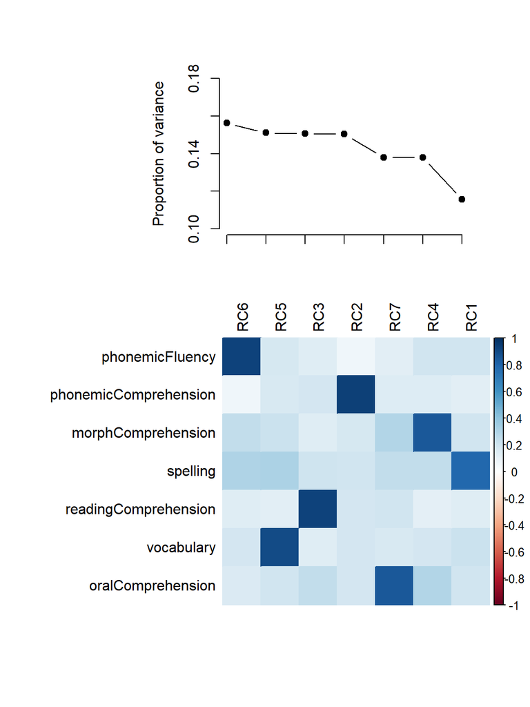

## Distribution of accuracy as a function of proficiency

Reviewers asked us the distribution of accuracy obtained by each participant in L2 against the standardized score in each proficiency subtest.

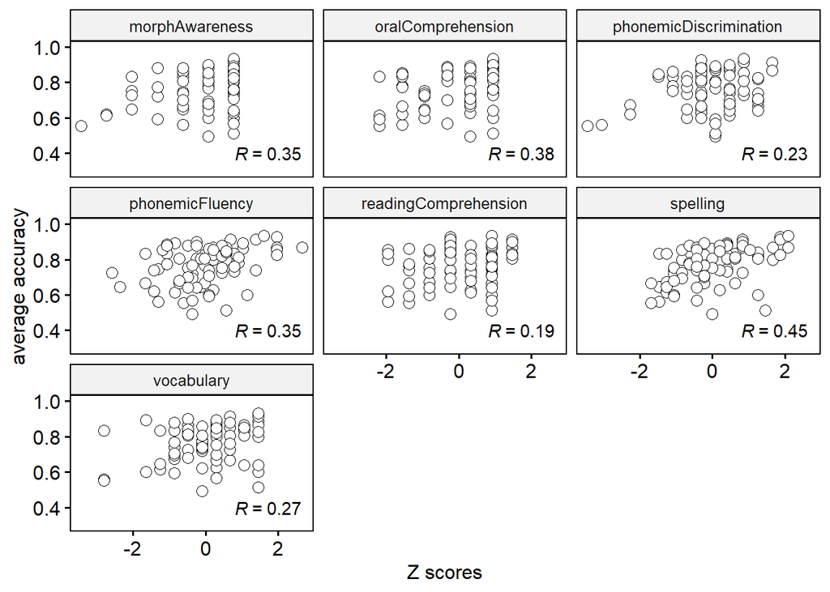

# Proficiency modelling

Set base contrasts to orthographic

```r
dataEng$morphType <- relevel(dataEng$morphType, "or");
```

This model establishes the baseline model, with no proficiency score:

```r
proficiencyglmer0 <- glmer(rt ~ relatedness * morphType  + freqTarget + lengthTarget + (1|subject) + (1|target), data = dataEng, family=Gamma(link="identity"), control=glmerControl(optimizer="bobyqa", optCtrl=list(maxfun=2e5)))
```

Now we test whether each individual proficiency score guarantees a better fit overall:

## Phonemic fluency

```r
proficiencyglmer1 <- glmer(rt ~ relatedness  * morphType * phonemicFluency + lengthTarget + freqTarget + (1|subject)
      + (1|target), data = dataEng, family=Gamma(link="identity"), control=glmerControl(optimizer="bobyqa", optCtrl=list(maxfun=2e5)));
anova(proficiencyglmer0, proficiencyglmer1);
```

## Phonemic comprehension

```r
proficiencyglmer2<- glmer(rt ~ relatedness  * morphType * phonemicComprehension + lengthTarget + freqTarget + (1|subject)
         + (1|target), data = dataEng, family=Gamma(link="identity"), control=glmerControl(optimizer="bobyqa"), optCtrl=list(maxfun=2e5)));
anova(proficiencyglmer0, proficiencyglmer2);
```

## Morphological awareness

```r
proficiencyglmer3<- glmer(rt ~ relatedness  * morphType * morphComprehension + lengthTarget + freqTarget + (1|subject) + (1|target), data = dataEng, family=Gamma(link="identity"), control=glmerControl(optimizer="bobyqa",optCtrl=list(maxfun=2e5)));
anova(proficiencyglmer0, proficiencyglmer3);
```

## Spelling

```r
proficiencyglmer4<- glmer(rt ~ relatedness  * morphType * spelling + lengthTarget + freqTarget + (1|subject) + (1|target), data = dataEng, family=Gamma(link="identity"), control=glmerControl(optimizer="bobyqa", optCtrl=list(maxfun=2e5)));
anova(proficiencyglmer0, proficiencyglmer4);
```

## Reading comprehension

```r
proficiencyglmer5<- glmer(rt ~ relatedness  * morphType * readingComprehension + lengthTarget + freqTarget + (1|subject) + (1|target), data = dataEng, family=Gamma(link="identity"), control=glmerControl(optimizer="bobyqa", optCtrl=list(maxfun=2e5)));
anova(proficiencyglmer0, proficiencyglmer5);
```

## Vocabulary

```r
proficiencyglmer6<- glmer(rt ~ relatedness  * morphType * vocabulary + lengthTarget + freqTarget + (1|subject) + (1|target), data = dataEng, family=Gamma(link="identity"), control=glmerControl(optimizer="bobyqa", optCtrl=list(maxfun=2e5)));
anova(proficiencyglmer0, proficiencyglmer6);
```

## Oral comprehension

```r
proficiencyglmer7<- glmer(rt ~ relatedness  * morphType * oralComprehension + lengthTarget + freqTarget + (1|subject) + (1|target), data = dataEng, family=Gamma(link="identity"), control=glmerControl(optimizer="bobyqa", optCtrl=list(maxfun=2e5)));
anova(proficiencyglmer0, proficiencyglmer7);
```

# Does proficiency specifically interact with priming?

We’re going to inspect the anova of each model first, so that we understand which metric we can focus on.

```r
car::Anova(proficiencyglmer1) -> proficiencyglmer1.anova
car::Anova(proficiencyglmer2) -> proficiencyglmer2.anova
car::Anova(proficiencyglmer3) -> proficiencyglmer3.anova
car::Anova(proficiencyglmer4) -> proficiencyglmer4.anova
car::Anova(proficiencyglmer5) -> proficiencyglmer5.anova
car::Anova(proficiencyglmer6) -> proficiencyglmer6.anova
car::Anova(proficiencyglmer7) -> proficiencyglmer7.anova
proficiencyglmer1.anova
```

```
## Analysis of Deviance Table (Type II Wald chisquare tests)
##
## Response: rt
##                                          Chisq Df Pr(>Chisq)
## relatedness                           153.0594  1  < 2.2e-16 ***
## morphType                              39.9565  2  2.106e-09 ***
## phonemicFluency                         0.5884  1   0.443039
## lengthTarget                           39.4061  1  3.442e-10 ***
## freqTarget                            636.0534  1  < 2.2e-16 ***
## relatedness:morphType                  11.5772  2   0.003062 **
## relatedness:phonemicFluency             4.4463  1   0.034978 *
## morphType:phonemicFluency              19.9921  2  4.558e-05 ***
## relatedness:morphType:phonemicFluency   3.6259  2   0.163172
## ---
## Signif. codes:  0 '***' 0.001 '**' 0.01 '*' 0.05 '.' 0.1 ' ' 1
```

```r
proficiencyglmer2.anova
```

```
## Analysis of Deviance Table (Type II Wald chisquare tests)
##
## Response: rt
##                                                Chisq Df Pr(>Chisq)
## relatedness                                 190.6468  1  < 2.2e-16 ***
## morphType                                    38.4328  2  4.513e-09 ***
## phonemicComprehension                         4.2647  1    0.03891 *
## lengthTarget                                 38.6991  1  4.944e-10 ***
## freqTarget                                  247.5258  1  < 2.2e-16 ***
## relatedness:morphType                        94.7005  2  < 2.2e-16 ***
## relatedness:phonemicComprehension             4.5962  1    0.03204 *
## morphType:phonemicComprehension              23.3758  2  8.395e-06 ***
## relatedness:morphType:phonemicComprehension  42.5724  2  5.695e-10 ***
## ---
## Signif. codes:  0 '***' 0.001 '**' 0.01 '*' 0.05 '.' 0.1 ' ' 1
```

```r
proficiencyglmer3.anova
```

```
## Analysis of Deviance Table (Type II Wald chisquare tests)
##
## Response: rt
##                                            Chisq Df Pr(>Chisq)
## relatedness                              152.563  1  < 2.2e-16 ***
## morphType                                524.480  2  < 2.2e-16 ***
## morphComprehension                        31.407  1  2.092e-08 ***
## lengthTarget                              51.218  1  8.265e-13 ***
## freqTarget                               215.887  1  < 2.2e-16 ***
## relatedness:morphType                    108.661  2  < 2.2e-16 ***
## relatedness:morphComprehension            23.800  1  1.069e-06 ***
## morphType:morphComprehension              54.872  2  1.215e-12 ***
## relatedness:morphType:morphComprehension  16.297  2  0.0002891 ***
## ---
## Signif. codes:  0 '***' 0.001 '**' 0.01 '*' 0.05 '.' 0.1 ' ' 1
```

```r
proficiencyglmer4.anova
```

```
## Analysis of Deviance Table (Type II Wald chisquare tests)
##
## Response: rt
##                                   Chisq Df Pr(>Chisq)
## relatedness                    134.1645  1  < 2.2e-16 ***
## morphType                       27.4114  2  1.116e-06 ***
## spelling                         1.7117  1    0.19076
## lengthTarget                    43.1821  1  4.987e-11 ***
## freqTarget                     484.5839  1  < 2.2e-16 ***
## relatedness:morphType           30.6629  2  2.196e-07 ***
## relatedness:spelling             4.7912  1    0.02861 *
## morphType:spelling              19.0341  2  7.359e-05 ***
## relatedness:morphType:spelling   1.4888  2    0.47502
## ---
## Signif. codes:  0 '***' 0.001 '**' 0.01 '*' 0.05 '.' 0.1 ' ' 1
```

```r
proficiencyglmer5.anova
```

```
## Analysis of Deviance Table (Type II Wald chisquare tests)
##
## Response: rt
##                                               Chisq Df Pr(>Chisq)
## relatedness                                107.3151  1  < 2.2e-16 ***
## morphType                                   30.6589  2  2.200e-07 ***
## readingComprehension                         2.8110  1    0.09362 .
## lengthTarget                                47.2183  1  6.350e-12 ***
## freqTarget                                 238.0712  1  < 2.2e-16 ***
## relatedness:morphType                        2.9111  2    0.23327
## relatedness:readingComprehension             0.4667  1    0.49450
## morphType:readingComprehension              24.5211  2  4.735e-06 ***
## relatedness:morphType:readingComprehension   4.7872  2    0.09130 .
## ---
## Signif. codes:  0 '***' 0.001 '**' 0.01 '*' 0.05 '.' 0.1 ' ' 1
```

```r
proficiencyglmer6.anova
```

```
## Analysis of Deviance Table (Type II Wald chisquare tests)
##
## Response: rt
##                                    Chisq Df Pr(>Chisq)
## relatedness                      363.795  1  < 2.2e-16 ***
## morphType                        100.233  2  < 2.2e-16 ***
## vocabulary                         1.540  1     0.2146
## lengthTarget                      26.524  1  2.603e-07 ***
## freqTarget                       403.518  1  < 2.2e-16 ***
## relatedness:morphType             51.289  2  7.290e-12 ***
## relatedness:vocabulary            64.775  1  8.397e-16 ***
## morphType:vocabulary              25.618  2  2.737e-06 ***
## relatedness:morphType:vocabulary  39.369  2  2.826e-09 ***
## ---
## Signif. codes:  0 '***' 0.001 '**' 0.01 '*' 0.05 '.' 0.1 ' ' 1
```

```r
proficiencyglmer7.anova
```

```
## Analysis of Deviance Table (Type II Wald chisquare tests)
##
## Response: rt
##                                            Chisq Df Pr(>Chisq)
## relatedness                             148.4503  1  < 2.2e-16 ***
## morphType                               138.1402  2  < 2.2e-16 ***
## oralComprehension                         0.4328  1    0.51063
## lengthTarget                             91.6203  1  < 2.2e-16 ***
## freqTarget                              352.8560  1  < 2.2e-16 ***
## relatedness:morphType                    20.9182  2  2.869e-05 ***
## relatedness:oralComprehension             3.0700  1    0.07975 .
## morphType:oralComprehension              21.3570  2  2.303e-05 ***
## relatedness:morphType:oralComprehension   0.7190  2    0.69802
## ---
## Signif. codes:  0 '***' 0.001 '**' 0.01 '*' 0.05 '.' 0.1 ' ' 1
```

Phonemic discrimination, morphological awareness and vocabulary are clearly significant; we will explore these effects in depth below. Oral comprehension and spelling are clearly non-significant, so we’ll just drop them. Phonemic fluency and reading comprehension do not pass the significance test; therefore, coherently with our rather conservative approach, we will not discuss them in the paper. However, they are relatively close to significance, so we will explore them slightly more in depth in this script – the user will decide for her/himself what to do of this additional evidence.

## The fully significant effects: phonemic discrimination, morphological awareness and vocabulary.

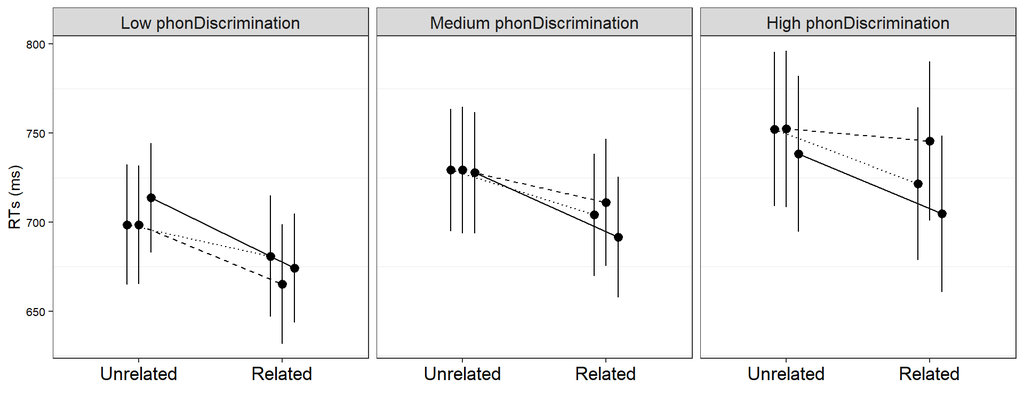

It seems that opaque and transparent priming are both strong across the phonemic discrimination scale, while orthographic priming shrinks to zero with growing phonemic discrimination. This is confirmed by the model parameters:

```r
knitr::kable(round(summary(proficiencyglmer2)$coefficients,3));
```

|  | Estimate | Std. Error | t value | Pr(>\|z\|) |
| --- | --- | --- | --- | --- |
| (Intercept) | 1081.793 | 10.741 | 100.717 | 0.000 |
| relatednessrel | -52.251 | 4.227 | -12.362 | 0.000 |
| morphTypeop | 0.142 | 5.720 | 0.025 | 0.980 |
| morphTypetr | 36.000 | 4.436 | 8.115 | 0.000 |
| phonemicComprehension | 7.679 | 2.609 | 2.943 | 0.003 |
| lengthTarget | -26.532 | 4.265 | -6.221 | 0.000 |
| freqTarget | -72.344 | 4.598 | -15.733 | 0.000 |
| relatednessrel:morphTypeop | 43.967 | 3.954 | 11.118 | 0.000 |
| relatednessrel:morphTypetr | 8.544 | 4.176 | 2.046 | 0.041 |
| relatednessrel:phonemicComprehension | 3.787 | 0.716 | 5.292 | 0.000 |
| morphTypeop:phonemicComprehension | -0.016 | 1.156 | -0.014 | 0.989 |
| morphTypetr:phonemicComprehension | -4.163 | 1.151 | -3.616 | 0.000 |
| relatednessrel:morphTypeop:phonemicComprehension | -5.658 | 0.877 | -6.452 | 0.000 |
| relatednessrel:morphTypetr:phonemicComprehension | -2.942 | 0.853 | -3.451 | 0.001 |

But we can see better here, where the orthographic condition is not the baseline and therefore it is explicitly pitted against one of the others (opaque, in this case):

```r
dataEng$morphType <- relevel(dataEng$morphType, "op");
```

```r
proficiencyglmer2b <- glmer(rt ~ relatedness  * morphType * phonemicComprehension + lengthTarget + freqTarget + (1|subject) + (1|target), data = dataEng, family=Gamma(link="identity"), control=glmerControl(optimizer="bobyqa"), optCtrl=list(maxfun=2e5)));
```

```r
knitr::kable(round(summary(proficiencyglmer2b)$coefficients,3));
```

|  | Estimate | Std. Error | t value | Pr(>\|z\|) |
| --- | --- | --- | --- | --- |
| (Intercept) | 1057.232 | 3.427 | 308.516 | 0.000 |
| relatednessrel | -24.058 | 3.149 | -7.641 | 0.000 |
| morphTypeor | -5.476 | 3.936 | -1.391 | 0.164 |
| morphTypetr | 26.654 | 3.261 | 8.172 | 0.000 |
| phonemicComprehension | 6.914 | 2.207 | 3.133 | 0.002 |
| lengthTarget | -27.461 | 3.432 | -8.001 | 0.000 |
| freqTarget | -68.173 | 2.901 | -23.496 | 0.000 |
| relatednessrel:morphTypeor | -10.178 | 3.983 | -2.556 | 0.011 |
| relatednessrel:morphTypetr | -16.357 | 3.711 | -4.408 | 0.000 |
| relatednessrel:phonemicComprehension | -0.215 | 0.564 | -0.382 | 0.702 |
| morphTypeor:phonemicComprehension | 0.829 | 0.961 | 0.863 | 0.388 |
| morphTypetr:phonemicComprehension | -2.853 | 0.934 | -3.054 | 0.002 |
| relatednessrel:morphTypeor:phonemicComprehension | 2.312 | 0.769 | 3.006 | 0.003 |
| relatednessrel:morphTypetr:phonemicComprehension | 0.546 | 0.729 | 0.749 | 0.454 |

A similar pattern emerges with vocabulary, in particular for what concerns the orthographic and transparent conditions:

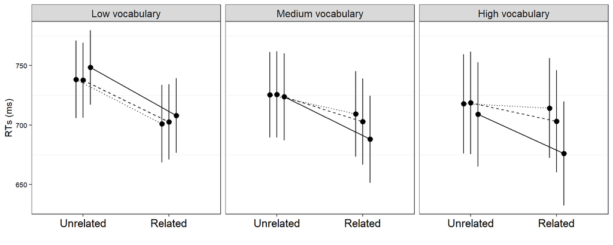

```r
round(summary(proficiencyglmer6)$coefficients,3);
```

```
##                                       Estimate Std. Error t value Pr(>|z|)
## (Intercept)                           1188.273      4.326 274.694    0.000
## relatednessrel                         -83.700      4.012 -20.863    0.000
## morphTypeop                             -2.816      3.409  -0.826    0.409
## morphTypetr                             35.814      3.894   9.197    0.000
## vocabulary                              -2.576      1.826  -1.411    0.158
## lengthTarget                           -26.626      5.170  -5.150    0.000
## freqTarget                             -72.201      3.594 -20.088    0.000
## relatednessrel:morphTypeop              21.415      3.869   5.534    0.000
## relatednessrel:morphTypetr              33.080      4.523   7.314    0.000
## relatednessrel:vocabulary                4.219      0.423   9.971    0.000
## morphTypeop:vocabulary                   0.190      0.830   0.228    0.819
## morphTypetr:vocabulary                  -2.350      0.829  -2.833    0.005
## relatednessrel:morphTypeop:vocabulary   -1.752      0.529  -3.313    0.001
## relatednessrel:morphTypetr:vocabulary   -3.285      0.529  -6.215    0.000
```

This time, though, also the opaque condition seems to flatten with growing proficiency, as we can see here:

```r
proficiencyglmer6b<- glmer(rt ~ relatedness  * morphType * vocabulary + lengthTarget + freqTarget + (1|subject) + (1|target), data = dataEng, family=Gamma(link="identity"), control=glmerControl(optimizer="bobyqa", optCtrl=list(maxfun=2e5)));
```

```r
round(summary(proficiencyglmer6b)$coefficients,3);
```

```
##                                       Estimate Std. Error t value Pr(>|z|)
## (Intercept)                           1137.842      5.694 199.833    0.000
## relatednessrel                         -54.575      4.057 -13.452    0.000
## morphTypeor                              6.799      4.808   1.414    0.157
## morphTypetr                             47.119      4.897   9.622    0.000
## vocabulary                              -1.425      1.720  -0.828    0.407
## lengthTarget                           -27.757      3.976  -6.981    0.000
## freqTarget                             -67.316      3.495 -19.259    0.000
## relatednessrel:morphTypeor              -9.482      4.436  -2.137    0.033
## relatednessrel:morphTypetr              23.813      8.197   2.905    0.004
## relatednessrel:vocabulary                1.898      0.375   5.066    0.000
## morphTypeor:vocabulary                  -0.357      0.736  -0.485    0.628
## morphTypetr:vocabulary                  -2.959      0.707  -4.184    0.000
## relatednessrel:morphTypeor:vocabulary    1.230      0.484   2.542    0.011
## relatednessrel:morphTypetr:vocabulary   -2.326      0.623  -3.733    0.000
```

Essentially: both orthographic and opaque priming shrinks with growing vocabulary, as compared to transparent priming, which remains solid across the board. Opaque priming, however, flattens less than orthographic priming, that is, there’s still a genuine morphological effect here, although morpho-orthographic differs from morpho-semantic. From a different perspective, the pattern with orthographic and transparent priming confirms what we see through phonemic awareness; the opaque priming pattern is different from phonemic awareness, instead.

Morphological awareness is a bit different, instead:

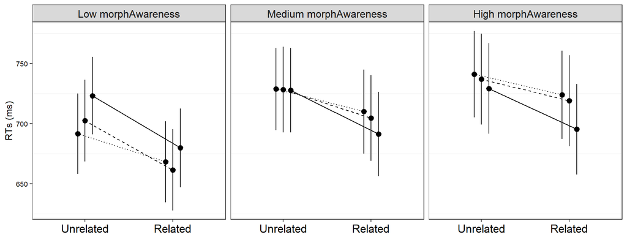

```r
knitr::kable(round(summary(proficiencyglmer3)$coefficients,3));
```

|  | Estimate | Std. Error | t value | Pr(>\|z\|) |
| --- | --- | --- | --- | --- |
| (Intercept) | 1038.946 | 6.175 | 168.255 | 0.000 |
| relatednessrel | -32.458 | 4.519 | -7.182 | 0.000 |
| morphTypeop | 33.826 | 5.483 | 6.169 | 0.000 |
| morphTypetr | 97.308 | 4.918 | 19.787 | 0.000 |
| morphComprehension | 12.417 | 2.477 | 5.012 | 0.000 |
| lengthTarget | -26.462 | 3.698 | -7.157 | 0.000 |
| freqTarget | -72.502 | 4.934 | -14.693 | 0.000 |
| relatednessrel:morphTypeop | -43.041 | 6.412 | -6.713 | 0.000 |
| relatednessrel:morphTypetr | -25.142 | 3.917 | -6.419 | 0.000 |
| relatednessrel:morphComprehension | 1.522 | 0.799 | 1.905 | 0.057 |
| morphTypeop:morphComprehension | -3.803 | 1.416 | -2.686 | 0.007 |
| morphTypetr:morphComprehension | -10.924 | 1.427 | -7.653 | 0.000 |
| relatednessrel:morphTypeop:morphComprehension | 4.234 | 1.049 | 4.037 | 0.000 |
| relatednessrel:morphTypetr:morphComprehension | 0.845 | 0.866 | 0.976 | 0.329 |

```r
proficiencyglmer3b <- glmer(rt ~ relatedness  * morphType * morphComprehension + lengthTarget + freqTarget + (1|subject) + (1|target), data = dataEng, family=Gamma(link="identity"), control=glmerControl(optimizer="bobyqa",optCtrl=list(maxfun=2e5)));
```

```r
knitr::kable(round(summary(proficiencyglmer3b)$coefficients,3));
```

|  | Estimate | Std. Error | t value | Pr(>\|z\|) |
| --- | --- | --- | --- | --- |
| (Intercept) | 1054.603 | 4.569 | 230.836 | 0.000 |
| relatednessrel | -71.051 | 4.355 | -16.317 | 0.000 |
| morphTypeor | -30.166 | 6.151 | -4.904 | 0.000 |
| morphTypetr | 49.545 | 4.668 | 10.614 | 0.000 |
| morphComprehension | 6.901 | 2.501 | 2.759 | 0.006 |
| lengthTarget | -27.045 | 3.273 | -8.262 | 0.000 |
| freqTarget | -68.146 | 4.354 | -15.652 | 0.000 |
| relatednessrel:morphTypeor | 44.305 | 7.087 | 6.252 | 0.000 |
| relatednessrel:morphTypetr | 37.153 | 4.979 | 7.462 | 0.000 |
| relatednessrel:morphComprehension | 5.165 | 0.652 | 7.916 | 0.000 |
| morphTypeor:morphComprehension | 3.599 | 1.252 | 2.875 | 0.004 |
| morphTypetr:morphComprehension | -5.332 | 1.209 | -4.412 | 0.000 |
| relatednessrel:morphTypeor:morphComprehension | -3.947 | 1.022 | -3.862 | 0.000 |
| relatednessrel:morphTypetr:morphComprehension | -5.585 | 0.849 | -6.581 | 0.000 |

Indeed, opaque differs from both orthographic and transparent, but transparent and orthographic do NOT differ. Quite different from what we observe anove for phonemic discrimination and vocabulary.

## The quasi-significant effects: phonemic fluency and reading comprehension

```r
knitr::kable(round(summary(proficiencyglmer1)$coefficients,3));
```

|  | Estimate | Std. Error | t value | Pr(>\|z\|) |
| --- | --- | --- | --- | --- |
| (Intercept) | 1134.612 | 4.222 | 268.721 | 0.000 |
| relatednessrel | -31.603 | 3.757 | -8.411 | 0.000 |
| morphTypeop | 4.769 | 3.935 | 1.212 | 0.226 |
| morphTypetr | 24.701 | 3.990 | 6.191 | 0.000 |
| phonemicFluency | 0.705 | 1.065 | 0.662 | 0.508 |
| lengthTarget | -26.837 | 4.275 | -6.277 | 0.000 |
| freqTarget | -72.210 | 2.863 | -25.220 | 0.000 |
| relatednessrel:morphTypeop | -14.234 | 8.287 | -1.718 | 0.086 |
| relatednessrel:morphTypetr | -6.926 | 3.728 | -1.858 | 0.063 |
| relatednessrel:phonemicFluency | 0.556 | 0.268 | 2.071 | 0.038 |
| morphTypeop:phonemicFluency | -0.219 | 0.402 | -0.545 | 0.585 |
| morphTypetr:phonemicFluency | -1.122 | 0.382 | -2.940 | 0.003 |
| relatednessrel:morphTypeop:phonemicFluency | 0.407 | 0.441 | 0.922 | 0.356 |
| relatednessrel:morphTypetr:phonemicFluency | -0.449 | 0.330 | -1.359 | 0.174 |

```r
knitr::kable(round(summary(proficiencyglmer5)$coefficients,3));
```

|  | Estimate | Std. Error | t value | Pr(>\|z\|) |
| --- | --- | --- | --- | --- |
| (Intercept) | 1120.024 | 4.925 | 227.403 | 0.000 |
| relatednessrel | -30.290 | 6.605 | -4.586 | 0.000 |
| morphTypeop | 7.729 | 8.289 | 0.932 | 0.351 |
| morphTypetr | 25.356 | 5.104 | 4.968 | 0.000 |
| readingComprehension | 6.553 | 3.760 | 1.743 | 0.081 |
| lengthTarget | -26.444 | 3.848 | -6.872 | 0.000 |
| freqTarget | -72.348 | 4.689 | -15.430 | 0.000 |
| relatednessrel:morphTypeop | 6.519 | 10.063 | 0.648 | 0.517 |
| relatednessrel:morphTypetr | 2.876 | 7.939 | 0.362 | 0.717 |
| relatednessrel:readingComprehension | 2.512 | 1.669 | 1.505 | 0.132 |
| morphTypeop:readingComprehension | -1.753 | 1.907 | -0.919 | 0.358 |
| morphTypetr:readingComprehension | -5.857 | 1.900 | -3.083 | 0.002 |
| relatednessrel:morphTypeop:readingComprehension | -2.693 | 2.444 | -1.102 | 0.271 |
| relatednessrel:morphTypetr:readingComprehension | -4.526 | 2.107 | -2.148 | 0.032 |

```r
proficiencyglmer1b <- glmer(rt ~ relatedness  * morphType * phonemicFluency + lengthTarget + freqTarget + (1|subject)
      + (1|target), data = dataEng, family=Gamma(link="identity"), control=glmerControl(optimizer="bobyqa", optCtrl=list(maxfun=2e5)));

proficiencyglmer5b<- glmer(rt ~ relatedness  * morphType * readingComprehension + lengthTarget + freqTarget + (1|subject) + (1|target), data = dataEng, family=Gamma(link="identity"), control=glmerControl(optimizer="bobyqa",optCtrl=list(maxfun=2e5)));
```

```r
knitr::kable(round(summary(proficiencyglmer1b)$coefficients,3));
```

|  | Estimate | Std. Error | t value | Pr(>\|z\|) |
| --- | --- | --- | --- | --- |
| (Intercept) | 1139.318 | 3.355 | 339.569 | 0.000 |
| relatednessrel | -45.832 | 3.945 | -11.617 | 0.000 |
| morphTypeor | -4.758 | 3.778 | -1.259 | 0.208 |
| morphTypetr | 19.940 | 3.791 | 5.260 | 0.000 |
| phonemicFluency | 0.487 | 0.954 | 0.510 | 0.610 |
| lengthTarget | -26.831 | 3.028 | -8.860 | 0.000 |
| freqTarget | -72.206 | 3.342 | -21.607 | 0.000 |
| relatednessrel:morphTypeor | 14.227 | 3.922 | 3.627 | 0.000 |
| relatednessrel:morphTypetr | 7.300 | 3.865 | 1.889 | 0.059 |
| relatednessrel:phonemicFluency | 0.962 | 0.263 | 3.665 | 0.000 |
| morphTypeor:phonemicFluency | 0.219 | 0.390 | 0.561 | 0.575 |
| morphTypetr:phonemicFluency | -0.903 | 0.373 | -2.422 | 0.015 |
| relatednessrel:morphTypeor:phonemicFluency | -0.406 | 0.340 | -1.194 | 0.232 |
| relatednessrel:morphTypetr:phonemicFluency | -0.855 | 0.321 | -2.666 | 0.008 |

```r
knitr::kable(round(summary(proficiencyglmer5b)$coefficients,3));
```

|  | Estimate | Std. Error | t value | Pr(>\|z\|) |
| --- | --- | --- | --- | --- |
| (Intercept) | 1012.753 | 31.772 | 31.876 | 0.000 |
| relatednessrel | -21.311 | 12.170 | -1.751 | 0.080 |
| morphTypeor | 2.439 | 14.316 | 0.170 | 0.865 |
| morphTypetr | 21.040 | 13.804 | 1.524 | 0.127 |
| readingComprehension | 7.540 | 3.182 | 2.370 | 0.018 |
| lengthTarget | -23.368 | 4.258 | -5.489 | 0.000 |
| freqTarget | -64.439 | 3.874 | -16.632 | 0.000 |
| relatednessrel:morphTypeor | -3.189 | 17.752 | -0.180 | 0.857 |
| relatednessrel:morphTypetr | -5.273 | 16.771 | -0.314 | 0.753 |
| relatednessrel:readingComprehension | -0.968 | 2.584 | -0.375 | 0.708 |
| morphTypeor:readingComprehension | 0.306 | 2.721 | 0.112 | 0.910 |
| morphTypetr:readingComprehension | -5.233 | 2.582 | -2.026 | 0.043 |
| relatednessrel:morphTypeor:readingComprehension | 2.955 | 3.772 | 0.784 | 0.433 |
| relatednessrel:morphTypetr:readingComprehension | -1.308 | 3.539 | -0.370 | 0.712 |

Both quasi-significances seem to come from specific contrasts between morphological conditions. For phonemic fluency, transparent primes seem to differ from opaque primes (but no other contrast is significant). For reading comprehension, transparent primes seem to differ from orthographic primes (but no other contrast is significant). Also, the contrast between transparent and opaque primes in the phonemic fluency analysis seems more convincing statistically (t = -2.66) than the contrast between transparent and orthographic primes in the reading comprehension analysis (t = -2.14).

As a bonus analysis, we exposed the coefficients for the proficiency interactions *for each morphological condition independently*. That is, we’re not comparing anymore conditions against each others; we evaluate here the change in the priming slope for each condition.

```r
proficiencyglmer2_estimate <-
  glmer(rt ~  relatedness + morphType + phonemicComprehension + relatedness:morphType +
          morphType:phonemicComprehension + relatedness:morphType:phonemicComprehension +
          lengthTarget + freqTarget + (1|subject) + (1|target),  data = dataEng, family=Gamma(link="identity"),
                                 control=glmerControl(optimizer="bobyqa", optCtrl=list(maxfun=2e5)));
```

```r
knitr::kable(round(summary(proficiencyglmer2_estimate)$coefficients,4))
```

|  | Estimate | Std. Error | t value | Pr(>\|z\|) |
| --- | --- | --- | --- | --- |
| (Intercept) | 1081.7836 | 4.3594 | 248.1504 | 0.0000 |
| relatednessrel | -52.2517 | 4.1777 | -12.5074 | 0.0000 |
| morphTypeop | 0.1503 | 3.7697 | 0.0399 | 0.9682 |
| morphTypetr | 36.0029 | 4.1837 | 8.6055 | 0.0000 |
| phonemicComprehension | 7.6793 | 2.5668 | 2.9918 | 0.0028 |
| lengthTarget | -26.5317 | 3.8623 | -6.8694 | 0.0000 |
| freqTarget | -72.3445 | 4.8251 | -14.9933 | 0.0000 |
| relatednessrel:morphTypeop | 43.9647 | 2.9949 | 14.6800 | 0.0000 |
| relatednessrel:morphTypetr | 8.5442 | 5.1788 | 1.6499 | 0.0990 |
| morphTypeop:phonemicComprehension | -0.0165 | 1.1615 | -0.0142 | 0.9887 |
| morphTypetr:phonemicComprehension | -4.1632 | 1.1070 | -3.7608 | 0.0002 |
| relatednessrel:morphTypeor:phonemicComprehension | 3.7868 | 0.7133 | 5.3089 | 0.0000 |
| relatednessrel:morphTypeop:phonemicComprehension | -1.8711 | 0.7602 | -2.4613 | 0.0138 |
| relatednessrel:morphTypetr:phonemicComprehension | 0.8444 | 0.8118 | 1.0401 | 0.2983 |

```r
proficiencyglmer3_estimate <-
  glmer(rt ~  relatedness + morphType + morphComprehension + relatedness:morphType +
          morphType:morphComprehension + relatedness:morphType:morphComprehension +
          lengthTarget + freqTarget + (1|subject) + (1|target),  data = dataEng, family=Gamma(link="identity"),
                                 control=glmerControl(optimizer="bobyqa", optCtrl=list(maxfun=2e5)));
```

```r
knitr::kable(round(summary(proficiencyglmer3_estimate)$coefficients,4))
```

|  | Estimate | Std. Error | t value | Pr(>\|z\|) |
| --- | --- | --- | --- | --- |
| (Intercept) | 1038.8757 | 3.4779 | 298.7098 | 0.0000 |
| relatednessrel | -32.4487 | 4.3033 | -7.5404 | 0.0000 |
| morphTypeop | 33.8294 | 4.3255 | 7.8210 | 0.0000 |
| morphTypetr | 97.3208 | 3.8174 | 25.4939 | 0.0000 |
| morphComprehension | 12.4229 | 2.3578 | 5.2689 | 0.0000 |
| lengthTarget | -26.4607 | 2.9062 | -9.1048 | 0.0000 |
| freqTarget | -72.5008 | 3.1049 | -23.3507 | 0.0000 |
| relatednessrel:morphTypeop | -43.0439 | 4.9341 | -8.7238 | 0.0000 |
| relatednessrel:morphTypetr | -25.1573 | 3.8750 | -6.4921 | 0.0000 |
| morphTypeop:morphComprehension | -3.8030 | 1.3792 | -2.7574 | 0.0058 |
| morphTypetr:morphComprehension | -10.9252 | 1.3830 | -7.8999 | 0.0000 |
| relatednessrel:morphTypeor:morphComprehension | 1.5210 | 0.7516 | 2.0236 | 0.0430 |
| relatednessrel:morphTypeop:morphComprehension | 5.7553 | 0.8710 | 6.6073 | 0.0000 |
| relatednessrel:morphTypetr:morphComprehension | 2.3676 | 0.8097 | 2.9239 | 0.0035 |

```r
proficiencyglmer6_estimate<- glmer(rt ~ relatedness  + morphType + vocabulary + relatedness:morphType + morphType:vocabulary + relatedness:morphType:vocabulary + lengthTarget + freqTarget + (1|subject) + (1|target),
                                data = dataEng, family=Gamma(link="identity"),
                                control=glmerControl(optimizer="bobyqa", optCtrl=list(maxfun=2e5)));
```

```r
knitr::kable(round(summary(proficiencyglmer6_estimate)$coefficients,4))
```

|  | Estimate | Std. Error | t value | Pr(>\|z\|) |
| --- | --- | --- | --- | --- |
| (Intercept) | 1185.5376 | 4.8303 | 245.4352 | 0.0000 |
| relatednessrel | -62.2591 | 4.8892 | -12.7341 | 0.0000 |
| morphTypeor | 2.8682 | 3.7764 | 0.7595 | 0.4476 |
| morphTypetr | 38.6580 | 3.3470 | 11.5499 | 0.0000 |
| vocabulary | -2.3893 | 1.8358 | -1.3015 | 0.1931 |
| lengthTarget | -26.6301 | 3.2221 | -8.2649 | 0.0000 |
| freqTarget | -72.2041 | 4.4155 | -16.3524 | 0.0000 |
| relatednessrel:morphTypeor | -21.4716 | 4.3941 | -4.8864 | 0.0000 |
| relatednessrel:morphTypetr | 11.6345 | 5.1225 | 2.2713 | 0.0231 |
| morphTypeor:vocabulary | -0.1926 | 0.8302 | -0.2319 | 0.8166 |
| morphTypetr:vocabulary | -2.5411 | 0.8059 | -3.1530 | 0.0016 |
| relatednessrel:morphTypeop:vocabulary | 2.4655 | 0.4517 | 5.4588 | 0.0000 |
| relatednessrel:morphTypeor:vocabulary | 4.2209 | 0.5349 | 7.8907 | 0.0000 |
| relatednessrel:morphTypetr:vocabulary | 0.9346 | 0.5741 | 1.6280 | 0.1035 |

## Jackknife

we further assessed the reliability of the proficiency results via a procedure —we repeatedly fitted the models described above to a subsample of the original observation set and checked that the model estimates remained fairly stable. These additional analyses fully confirm the pattern of results illustrated above, as shown in the figure below:

[figure not shown]

## Summary of results for the proficiency analysis

We assessed which proficiency score, if any, interacted specifically with prime relatedness and morphological condition. It turned out that this happens for:

The remaining tests – phonemic fluency, spelling, oral comprehension and reading comprehension— did not reach significance. Respectively: [$\chi^2$ = 3.63, $Df$ = 2, *p* = 0.16], [$\chi^2$ = 1.49, $Df$ = 2, *p* = 0.47], [$\chi^2$ = 0.72, $Df$ = 2, *p* = 0.69], [$\chi^2$ = 4.79, $Df$ = 2, *p* = 0.09].

# AoA

## Correlation

Correlation between the individual scores, and between aoa and proficiency:

```r
knitr::kable(round(cor(pptFeatures[,c(13,14,17)], use='pairwise.complete.obs', method='spearman'), digits=2));
```

|  | aoa1.Aoa | aoa2.usage | aoa5.selfRatedProf |
| --- | --- | --- | --- |
| aoa1.Aoa | 1.00 | -0.15 | 0.04 |
| aoa2.usage | -0.15 | 1.00 | 0.49 |
| aoa5.selfRatedProf | 0.04 | 0.49 | 1.00 |

```r
knitr::kable(round(cor(pptFeatures[,c(6:12, 13)], use='pairwise.complete.obs', method='spearman'), digits=2)[8,]);
```

|  | x |
| --- | --- |
| phonemicFluency | 0.04 |
| phonemicComprehension | -0.21 |
| morphComprehension | -0.13 |
| spelling | -0.23 |
| readingComprehension | -0.15 |
| vocabulary | -0.13 |
| oralComprehension | -0.19 |
| aoa1.Aoa | 1.00 |

## Modelling

Make sure the baseline is set to the “orthographic” condition:

```r
dataEng$morphType <- relevel(dataEng$morphType, "or");
```

We assess whether any AoA metric provides an increse in goodness of fit.

```r
aoaglmer1 <- glmer(rt ~ relatedness * morphType*aoa1.Aoa + freqTarget + lengthTarget + (1|subject) + (1|target), data= dataEng, family=Gamma(link="identity"), control=glmerControl(optimizer="bobyqa", optCtrl=list(maxfun=2e5)));
```

```r
anova(proficiencyglmer0, aoaglmer1)->goodness.aoa1
goodness.aoa1
```

```
## Data: dataEng
## Models:
## proficiencyglmer0: rt ~ relatedness * morphType + freqTarget + lengthTarget + (1 |
## proficiencyglmer0:     subject) + (1 | target)
## aoaglmer1: rt ~ relatedness * morphType * aoa1.Aoa + freqTarget + (1 | subject) +
## aoaglmer1:     (1 | target)
##                   npar    AIC    BIC logLik deviance  Chisq Df Pr(>Chisq)
## proficiencyglmer0   11 113629 113707 -56803   113607
## aoaglmer1           16 113636 113750 -56802   113604 2.3202  5     0.8033
```

```r
aoaglmer2 <- glmer(rt ~ relatedness * morphType*aoa2.usage + freqTarget + lengthTarget + (1|subject) + (1|target), data= dataEng, family=Gamma(link="identity"), control=glmerControl(optimizer="bobyqa", optCtrl=list(maxfun=2e5)));
```

```r
anova(proficiencyglmer0,aoaglmer2)->goodness.aoa2
goodness.aoa2
```

```
## Data: dataEng
## Models:
## proficiencyglmer0: rt ~ relatedness * morphType + freqTarget + lengthTarget + (1 |
## proficiencyglmer0:     subject) + (1 | target)
## aoaglmer2: rt ~ relatedness * morphType * aoa2.usage + freqTarget + (1 |
## aoaglmer2:     subject) + (1 | target)
##                   npar    AIC    BIC logLik deviance  Chisq Df Pr(>Chisq)
## proficiencyglmer0   11 113629 113707 -56803   113607
## aoaglmer2           16 113631 113745 -56800   113599 7.3367  5     0.1968
```

```r
aoaglmer3 <- glmer(rt ~ relatedness * morphType*aoa3.context + freqTarget + lengthTarget + (1|subject) + (1|target), data= dataEng, family=Gamma(link="identity"), control=glmerControl(optimizer="bobyqa", optCtrl=list(maxfun=2e5)));
```

```r
anova(proficiencyglmer0, aoaglmer3)->goodness.aoa3
goodness.aoa3
```

```
## Data: dataEng
## Models:
## proficiencyglmer0: rt ~ relatedness * morphType + freqTarget + lengthTarget + (1 |
## proficiencyglmer0:     subject) + (1 | target)
## aoaglmer3: rt ~ relatedness * morphType * aoa3.context + freqTarget + (1 |
## aoaglmer3:     subject) + (1 | target)
##                   npar    AIC    BIC logLik deviance Chisq Df Pr(>Chisq)
## proficiencyglmer0   11 113629 113707 -56803   113607
## aoaglmer3           16 113641 113755 -56805   113609     0  5          1
```

```r
aoaglmer4 <- glmer(rt ~ relatedness * morphType*aoa4.contextMultling + freqTarget + lengthTarget + (1|subject) + (1|target), data= dataEng, family=Gamma(link="identity"), control=glmerControl(optimizer="bobyqa", optCtrl=list(maxfun=2e5)));
```

```r
anova(proficiencyglmer0, aoaglmer4)->goodness.aoa4
goodness.aoa4
```

```
## Data: dataEng
## Models:
## proficiencyglmer0: rt ~ relatedness * morphType + freqTarget + lengthTarget + (1 |
## proficiencyglmer0:     subject) + (1 | target)
## aoaglmer4: rt ~ relatedness * morphType * aoa4.contextMultling + freqTarget +
## aoaglmer4:     (1 | subject) + (1 | target)
##                   npar    AIC    BIC logLik deviance Chisq Df Pr(>Chisq)
## proficiencyglmer0   11 113629 113707 -56803   113607
## aoaglmer4           16 113641 113755 -56805   113609     0  5          1
```

```r
aoaglmer5 <- glmer(rt ~ relatedness * morphType*aoa5.selfRatedProf + freqTarget + lengthTarget + (1|subject) + (1|target), data= dataEng, family=Gamma(link="identity"), control=glmerControl(optimizer="bobyqa", optCtrl=list(maxfun=2e5)));
```

```r
anova(proficiencyglmer0, aoaglmer5)->goodness.aoa5
goodness.aoa5
```

```
## Data: dataEng
## Models:
## proficiencyglmer0: rt ~ relatedness * morphType + freqTarget + lengthTarget + (1 |
## proficiencyglmer0:     subject) + (1 | target)
## aoaglmer5: rt ~ relatedness * morphType * aoa5.selfRatedProf + freqTarget +
## aoaglmer5:     lengthTarget + (1 | subject) + (1 | target)
##                   npar    AIC    BIC logLik deviance  Chisq Df Pr(>Chisq)
## proficiencyglmer0   11 113629 113707 -56803   113607
## aoaglmer5           17 113623 113744 -56794   113589 17.787  6   0.006789 **
## ---
## Signif. codes:  0 '***' 0.001 '**' 0.01 '*' 0.05 '.' 0.1 ' ' 1
```

```r
aoaglmer6 <- glmer(rt ~ relatedness * morphType*aoa6.otherLang + freqTarget + lengthTarget + (1|subject) + (1|target), data= dataEng, family=Gamma(link="identity"), control=glmerControl(optimizer="bobyqa", optCtrl=list(maxfun=2e5)));
```

```r
anova(proficiencyglmer0, aoaglmer6)->goodness.aoa6
goodness.aoa6
```

```
## Data: dataEng
## Models:
## proficiencyglmer0: rt ~ relatedness * morphType + freqTarget + lengthTarget + (1 |
## proficiencyglmer0:     subject) + (1 | target)
## aoaglmer6: rt ~ relatedness * morphType * aoa6.otherLang + freqTarget +
## aoaglmer6:     (1 | subject) + (1 | target)
##                   npar    AIC    BIC logLik deviance Chisq Df Pr(>Chisq)
## proficiencyglmer0   11 113629 113707 -56803   113607
## aoaglmer6           16 113644 113758 -56806   113612     0  5          1
```

It does not seem so, except for AoA5 (which is self-rated proficiency, so this confirms the objective-metrics proficiency analyses). Most notably, AoA proper doesn’t contribute any increase in goodness of fit. Let see whether AoA5 specifically modulate priming:

```r
car::Anova(aoaglmer5)-> aoaglmer5.anova
aoaglmer5.anova
```

```
## Analysis of Deviance Table (Type II Wald chisquare tests)
##
## Response: rt
##                                             Chisq Df Pr(>Chisq)
## relatedness                              208.3417  1  < 2.2e-16 ***
## morphType                                  7.5328  2   0.023135 *
## aoa5.selfRatedProf                         7.0812  1   0.007790 **
## freqTarget                               371.8232  1  < 2.2e-16 ***
## lengthTarget                              78.5755  1  < 2.2e-16 ***
## relatedness:morphType                    126.4083  2  < 2.2e-16 ***
## relatedness:aoa5.selfRatedProf            30.3694  1  3.571e-08 ***
## morphType:aoa5.selfRatedProf              10.1555  2   0.006234 **
## relatedness:morphType:aoa5.selfRatedProf  68.0810  2  1.646e-15 ***
## ---
## Signif. codes:  0 '***' 0.001 '**' 0.01 '*' 0.05 '.' 0.1 ' ' 1
```

They do, good. Let see how they do so:

```r
knitr::kable(round(summary(aoaglmer5)$coefficients,3));
```

|  | Estimate | Std. Error | t value | Pr(>\|z\|) |
| --- | --- | --- | --- | --- |
| (Intercept) | 1190.545 | 6.379 | 186.640 | 0.000 |
| relatednessrel | -70.980 | 5.075 | -13.987 | 0.000 |
| morphTypeop | 15.084 | 3.989 | 3.781 | 0.000 |
| morphTypetr | 8.521 | 3.951 | 2.157 | 0.031 |
| aoa5.selfRatedProf | -12.167 | 4.305 | -2.826 | 0.005 |
| freqTarget | -72.147 | 3.742 | -19.283 | 0.000 |
| lengthTarget | -26.565 | 2.997 | -8.864 | 0.000 |
| relatednessrel:morphTypeop | 41.771 | 3.941 | 10.599 | 0.000 |
| relatednessrel:morphTypetr | 31.286 | 4.072 | 7.683 | 0.000 |
| relatednessrel:aoa5.selfRatedProf | 14.763 | 1.710 | 8.633 | 0.000 |
| morphTypeop:aoa5.selfRatedProf | -4.198 | 2.716 | -1.546 | 0.122 |
| morphTypetr:aoa5.selfRatedProf | -2.541 | 2.347 | -1.083 | 0.279 |
| relatednessrel:morphTypeop:aoa5.selfRatedProf | -13.454 | 2.082 | -6.463 | 0.000 |
| relatednessrel:morphTypetr:aoa5.selfRatedProf | -13.773 | 1.981 | -6.952 | 0.000 |

```r
dataEng$morphType <- relevel(dataEng$morphType, "op");
```

```r
aoaglmer5c<- glmer(rt ~ relatedness * morphType*aoa5.selfRatedProf + freqTarget + (1|subject) + (1|target), data= dataEng, family=Gamma(link="identity"), control=glmerControl(optimizer="bobyqa", optCtrl=list(maxfun=2e5)));
```

```r
knitr::kable(round(summary(aoaglmer5c)$coefficients,3));
```

|  | Estimate | Std. Error | t value | Pr(>\|z\|) |
| --- | --- | --- | --- | --- |
| (Intercept) | 1069.768 | 4.334 | 246.849 | 0.000 |
| relatednessrel | -28.972 | 2.960 | -9.789 | 0.000 |
| morphTypeor | -10.267 | 4.187 | -2.452 | 0.014 |
| morphTypetr | -10.933 | 4.110 | -2.660 | 0.008 |
| aoa5.selfRatedProf | -16.351 | 3.698 | -4.421 | 0.000 |
| freqTarget | -69.245 | 2.948 | -23.489 | 0.000 |
| relatednessrel:morphTypeor | -41.714 | 3.564 | -11.705 | 0.000 |
| relatednessrel:morphTypetr | -10.577 | 3.838 | -2.756 | 0.006 |
| relatednessrel:aoa5.selfRatedProf | 1.241 | 1.390 | 0.893 | 0.372 |
| morphTypeor:aoa5.selfRatedProf | 4.218 | 2.603 | 1.620 | 0.105 |
| morphTypetr:aoa5.selfRatedProf | 1.645 | 2.324 | 0.708 | 0.479 |
| relatednessrel:morphTypeor:aoa5.selfRatedProf | 13.429 | 1.847 | 7.272 | 0.000 |
| relatednessrel:morphTypetr:aoa5.selfRatedProf | -0.307 | 1.857 | -0.165 | 0.869 |

# Summary of the results for the AoA and priming

We first assessed whether *AoA proper* allows an overall better account of RTs. This does not seem to be the case, [$\chi^2$ = 2.32, $Df$ = 5, p = .8].

Among the other scores that we collected via the AoA questionnaire, only *self-rated proficiency* improves the quality of the model predictions [$\chi^2$ = 17.79, $Df$ = 6, p = .006]. Self-rated proficiency also modulates priming: [$\chi^2$ = 68.08, $Df$ = 2, p $<$ .0001]. Orthographic priming shrinks with growing proficiency significantly more than both opaque, [$\beta$ = -13.45, $Std.Error$ = 2.08, $t$ = -6.46, *p* $<$ .0001], and transparent priming [$\beta$ = -13.77, $Std.Error$ = 1.98, $t$ = -6.95, *p* $<$ .0001]. While there is no difference between the latter two, [$\beta$ = -0.31, $Std.Error$ = 1.86, $t$ = -0.17, *p* = .86].

The remaining variables do not affect RTs.

- *AoA - daily usage*: [$\chi^2$ = 7.34, $Df$ = 5, p = .19]
- *AoA - Home vs School*: [$\chi^2$ = 0, $Df$ = 5, p = 1]
- *AoA - Multilingual context*: [$\chi^2$ = 0, $Df$ = 5, p = 1]
- *AoA - other languages*: [$\chi^2$ = 0, $Df$ = 5, p = 1]

# OSC

First, let’s try to pit OSC against priming condition – these two are typically confounded:

```r
temp <- unique(masterFile[masterFile$lexicality=='word' & masterFile$language=='eng',c('target','prime','morphType','relatedness','freqTarget','freqPrime','lengthTarget','lengthPrime','nTarget','nPrime','oscTarget')]);
```

```r
aggregate(oscTarget ~ morphType, FUN=fivenum, data=temp)
```

[output not shown]

Indeed they are. This tests it more formally:

```r
summary(aov(oscTarget~morphType, data=subset(temp, relatedness=='rel')));
```

```
##              Df Sum Sq Mean Sq F value   Pr(>F)
## morphType     2  3.433  1.7163   21.02 9.75e-09 ***
## Residuals   144 11.755  0.0816
## ---
## Signif. codes:  0 '***' 0.001 '**' 0.01 '*' 0.05 '.' 0.1 ' ' 1
## 3 observations deleted due to missingness
```

## modelling

```r
osc2 <- glmer(rt ~ relatedness *  oscTarget * phonemicComprehension + freqTarget + lengthTarget + (1|subject) + (1|target), data = dataEng, family=Gamma(link="identity"), control=glmerControl(optimizer="bobyqa", optCtrl=list(maxfun=2e5)));
```

```r
osc2.anova <- car::Anova(osc2);
```

```r
osc3 <- glmer(rt ~ relatedness *  oscTarget * morphComprehension + freqTarget + lengthTarget + (1|subject) + (1|target), data = dataEng, family=Gamma(link="identity"), control=glmerControl(optimizer="bobyqa", optCtrl=list(maxfun=2e5)));
```

```r
osc3.anova <- car::Anova(osc3);
```

```r
osc6 <- glmer(rt ~ relatedness *  oscTarget * vocabulary + freqTarget + lengthTarget + (1|subject) + (1|target), data = dataEng, family=Gamma(link="identity"), control=glmerControl(optimizer="bobyqa", optCtrl=list(maxfun=2e5)));
```

```r
osc6.anova <- car::Anova(osc6);
```

Morph awareness and vocabulary seem to work:

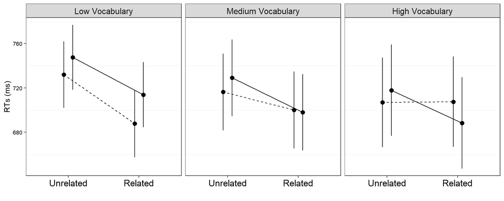

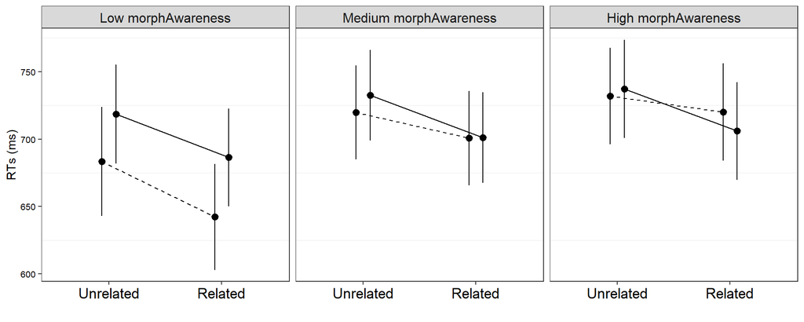

```r
knitr::kable(round(summary(osc3)$coefficients,3));
knitr::kable(round(summary(osc6)$coefficients,3));
```

[output not shown]

## OSC in unrelated trials

We have checked in the models here that OSC also has a main effect, and whether OSC has a main effect and/or interact with any of the proficiency metric when you consider RTs *only to unrelated trials*.

```r
osc1_unrelatedTrials <- glmer(rt ~ oscTarget * phonemicFluency + freqTarget + lengthTarget + (1|subject) + (1|target), data = dataEng[dataEng$relatedness=="ctrl",], family=Gamma(link="identity"), control=glmerControl(optimizer="bobyqa", optCtrl=list(maxfun=2e5)));
```

```r
osc1_unrelatedTrials.anova <- car::Anova(osc1_unrelatedTrials)
```

```r
osc2_unrelatedTrials <- glmer(rt ~  oscTarget * phonemicComprehension + freqTarget + lengthTarget + (1|subject) + (1|target), data = dataEng[dataEng$relatedness=="ctrl",], family=Gamma(link="identity"), control=glmerControl(optimizer="bobyqa", optCtrl=list(maxfun=2e5)));
```

```r
osc2_unrelatedTrials.anova <- car::Anova(osc2_unrelatedTrials)
```

```r
osc3_unrelatedTrials <- glmer(rt ~  oscTarget * morphComprehension + freqTarget + lengthTarget + (1|subject) + (1|target), data = dataEng[dataEng$relatedness=="ctrl",], family=Gamma(link="identity"), control=glmerControl(optimizer="bobyqa", optCtrl=list(maxfun=2e5)));
```

```r
osc3_unrelatedTrials.anova <-car::Anova(osc3_unrelatedTrials)
```

```r
osc4_unrelatedTrials <- glmer(rt ~  oscTarget * spelling + freqTarget + lengthTarget + (1|subject) + (1|target), data = dataEng[dataEng$relatedness=="ctrl",], family=Gamma(link="identity"), control=glmerControl(optimizer="bobyqa", optCtrl=list(maxfun=2e5)));
```

```r
osc4_unrelatedTrials.anova <-car::Anova(osc4_unrelatedTrials)
```

```r
osc5_unrelatedTrials <- glmer(rt ~  oscTarget * readingComprehension + freqTarget + lengthTarget + (1|subject) + (1|target), data = dataEng[dataEng$relatedness=="ctrl",], family=Gamma(link="identity"), control=glmerControl(optimizer="bobyqa", optCtrl=list(maxfun=2e5)));
```

```r
osc5_unrelatedTrials.anova <-car::Anova(osc5_unrelatedTrials)
```

```r
osc6_unrelatedTrials <- glmer(rt ~ oscTarget * vocabulary + freqTarget + lengthTarget + (1|subject) + (1|target), data = dataEng[dataEng$relatedness=="ctrl",], family=Gamma(link="identity"), control=glmerControl(optimizer="bobyqa", optCtrl=list(maxfun=2e5)));
```

```r
osc6_unrelatedTrials.anova <-car::Anova(osc6_unrelatedTrials)
```

```r
osc7_unrelatedTrials <- glmer(rt ~ oscTarget * oralComprehension + freqTarget + lengthTarget + (1|subject) + (1|target), data = dataEng[dataEng$relatedness=="ctrl",], family=Gamma(link="identity"), control=glmerControl(optimizer="bobyqa", optCtrl=list(maxfun=2e5)));
```

```r
osc7_unrelatedTrials.anova <-car::Anova(osc7_unrelatedTrials)
```

```r
osc2_unrelatedTrials.anova
```

```
## Analysis of Deviance Table (Type II Wald chisquare tests)
##
## Response: rt
##                                    Chisq Df Pr(>Chisq)
## oscTarget                        52.2337  1  4.927e-13 ***
## phonemicComprehension             3.6133  1  0.0573182 .
## freqTarget                      163.7216  1  < 2.2e-16 ***
## lengthTarget                     18.8224  1  1.435e-05 ***
## oscTarget:phonemicComprehension  13.0646  1  0.0003009 ***
## ---
## Signif. codes:  0 '***' 0.001 '**' 0.01 '*' 0.05 '.' 0.1 ' ' 1
```

```r
osc3_unrelatedTrials.anova
```

```
## Analysis of Deviance Table (Type II Wald chisquare tests)
##
## Response: rt
##                                Chisq Df Pr(>Chisq)
## oscTarget                    416.641  1  < 2.2e-16 ***
## morphComprehension            12.846  1  0.0003382 ***
## freqTarget                   241.197  1  < 2.2e-16 ***
## lengthTarget                  33.846  1  5.967e-09 ***
## oscTarget:morphComprehension  40.290  1  2.190e-10 ***
## ---
## Signif. codes:  0 '***' 0.001 '**' 0.01 '*' 0.05 '.' 0.1 ' ' 1
```

This checks whether OSC provides a better account for the data as compared to the more classic category distinction, as suggested by Reviewer 1:

```r
AIC(osc3); AIC(proficiencyglmer3); #this is for morphological awareness
```

```
## [1] 111639.7
```

```
## [1] 113613.5
```

```r
AIC(osc6); AIC(proficiencyglmer6); #this is for vocabulary
```

```
## [1] 111662.4
```

```
## [1] 113623.8
```

## Summary of results for OSC by proficiency

we also wanted to assess the role of Orthography–to–Semantics Consistency (OSC) in L2, and particularly whether this variable affects morphological priming.

There is a significant main effect of OSC in:

- *phonemic discrimination:* [$\chi^2$ = 199.68, $Df$ = 1, p $<$ .0001]
- *morphological awareness:* [$\chi^2$ = 442.95, $Df$ = 1, p $<$ .0001]
- *vocabulary:* [$\chi^2$ = 914.48, $Df$ = 1, p $<$ .0001]

Moreover, OSC modulates morphological priming in L2 via interactions with:

- *vocabulary:* [$\chi^2$ = 181.81, $Df$ = 1, p $<$ .0001]
- *morphological awareness:* [$\chi^2$ = 111.53, $Df$ = 1, p $<$ .0001]

Phonemic discrimination doesn’t modulate priming with OSC, [$\chi^2$ = 0.27, $Df$ = 1, p = .6]

# Plots

## Figure 1 - plot of estimated RTs

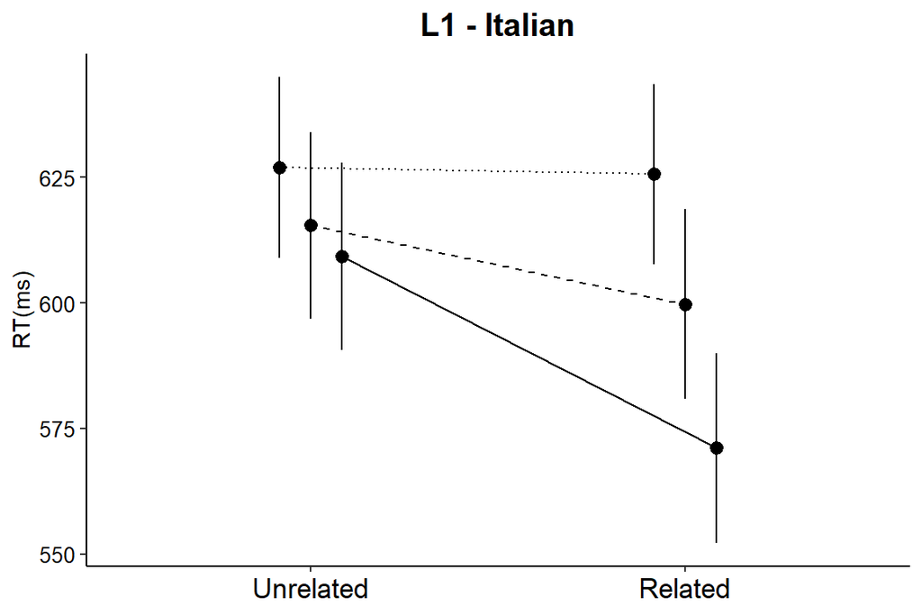

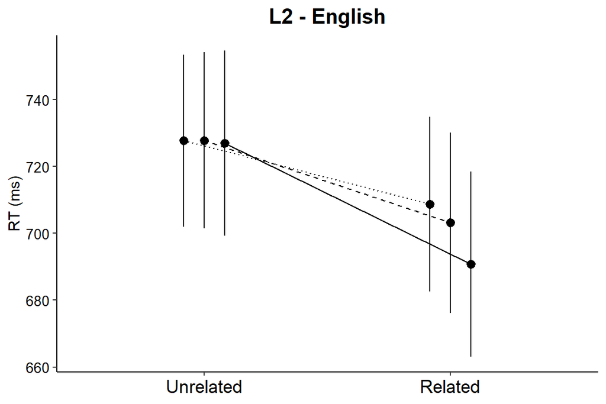

## Figure 2 - Participants’ score distributions for each proficiency subtest

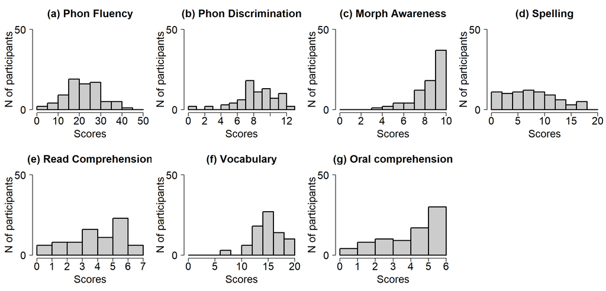

## Figure 3 - Interaction by phonemic discrimination by relatedness and morphtype

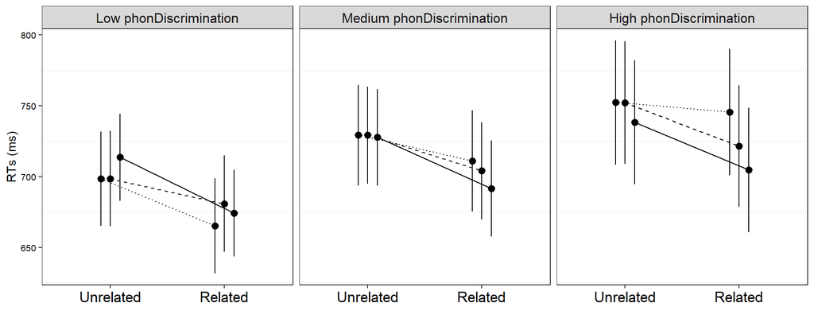

## Figure 4 - Interaction by vocabulary by relatedness and morphtype

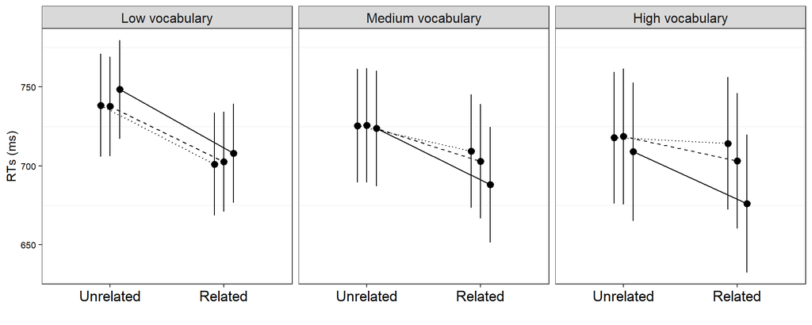

## Figure 5 - Interaction by morphological awareness by relatedness and morphtype

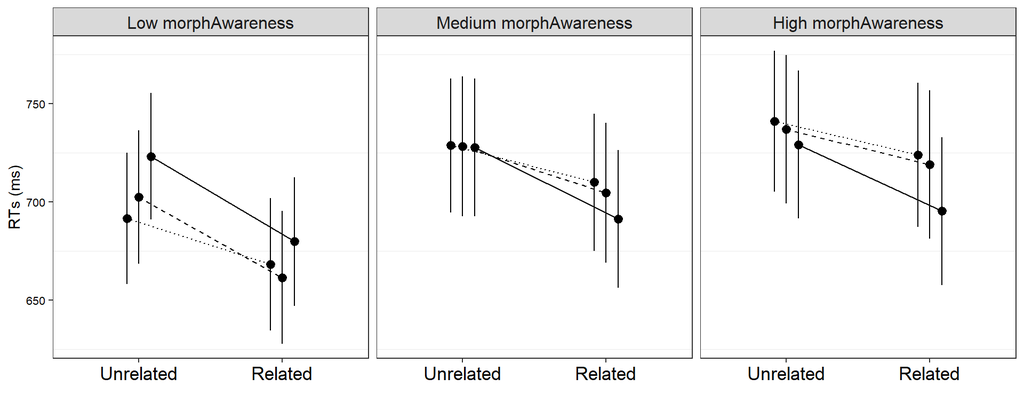

## Figure 6 - jackknife

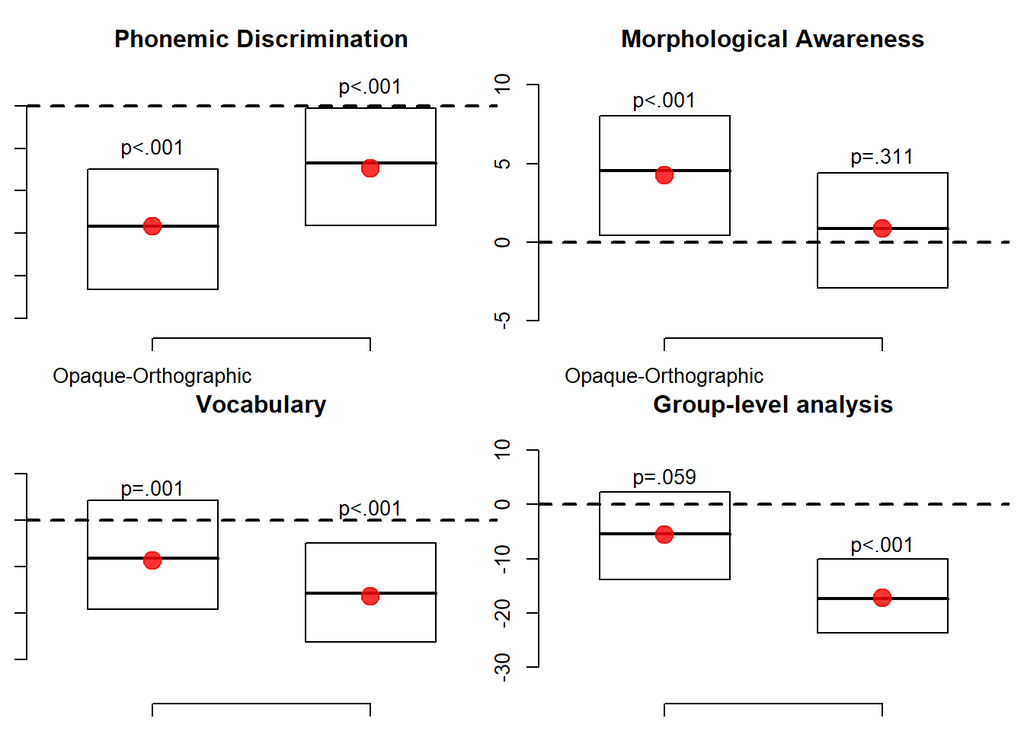

## Figure 7 - Scores distributions in the AoA questionnaire

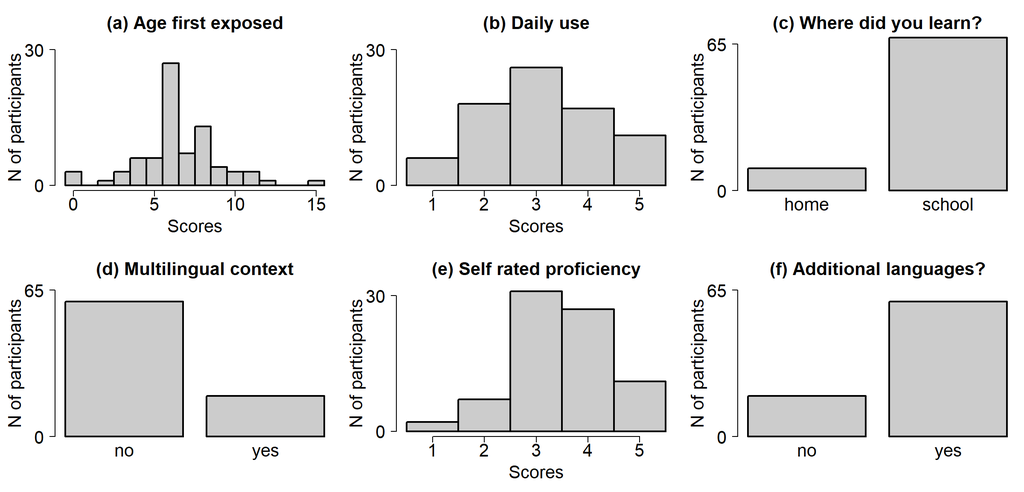

## Figure 8 - OSC boxplot distribution by morphtype

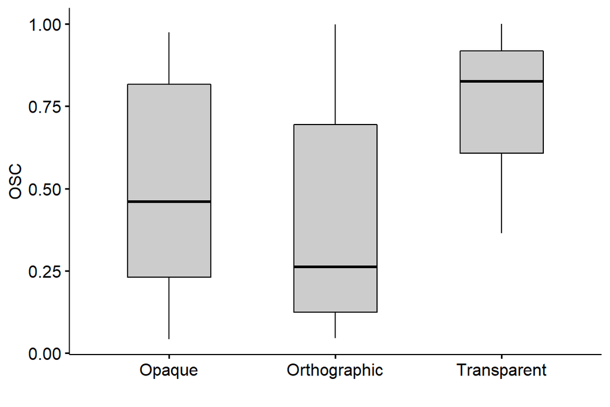

## Figure 9 - Osc and vocabulary

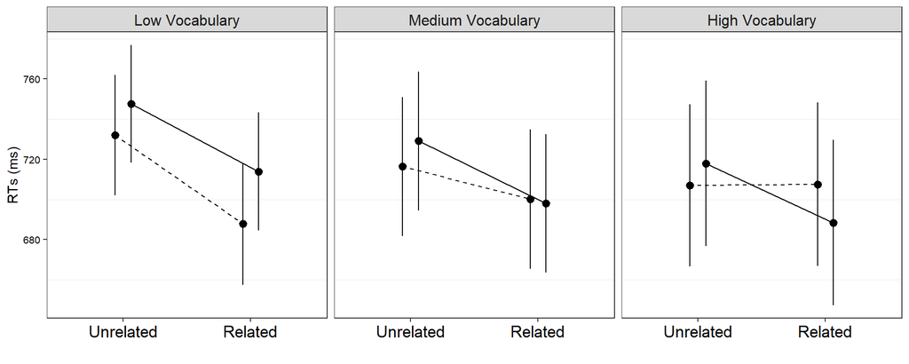

## Figure 10 - OSC and morphological awareness

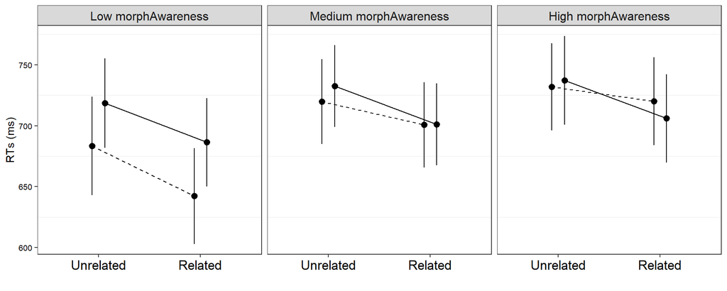